# Ficha de Información Metropolitana

Universidad Autónoma Metropolitnana

Lic. Martínez Rodriguez, Alvaro[^1]

Lic. Pérez Victorino, Leonardo[^2]

La ficha de información metropolitana es una herramienta valiosa para la planificación territorial en zonas metropolitanas (ZM). Proporciona información censal en diferentes formatos, como gráficos, tablas y mapas, tanto de los Censos de Población y Vivienda, 2020 (CPV2020) como de los Censos Económicos de 1999, 2004, 2009, 2014 y 2019. Ambos publicados por el Instituto Nacional de Estadística y Geografía (INEGI).

## Información general de la Zona Metropolitana de Cuautla

Según (Sedatu 2018), la zona metropolitana se define como un área urbana que consta de una ciudad principal y su zona conurbada. Las zonas metropolitanas se caracterizan por tener una alta densidad de población y estar interconectadas por vías de transporte y comunicación. La zona metropolitana de Cuautla, se localiza en Morelos. y esta compuesta por 6 municipios, que se muestran a continuación:

| Nombre | Clave |
| --- | --- |
| Atlatlahucan | 17002 |
| Ayala | 17004 |
| Cuautla | 17006 |
| Tlayacapan | 17026 |
| Yautepec | 17029 |
| Yecapixtla | 17030 |

Municipios de la zona metropolitana

Además, se presenta un mapa de la zona metropolitana:

[interactive chart not shown]

A continuación se presentan algunos datos generales sobre esta zona:

- Zona Metropolitana:Cuautla
- Número de municipios: 6
- Población total: 483,455
- Superficie de la ZM: 975.49 [m^2]
- Densidad poblacional: 495.602 [1/m^2] Hab/Km^2.
- Grado promedio de escolaridad: 9.2733333

## Información sociodemográfica

La estructura de población de la zona metropolitana de Cuautla se presenta en la una piramide poblacional ya que permite obtener una visión general de la distribución de la población por género y edad:

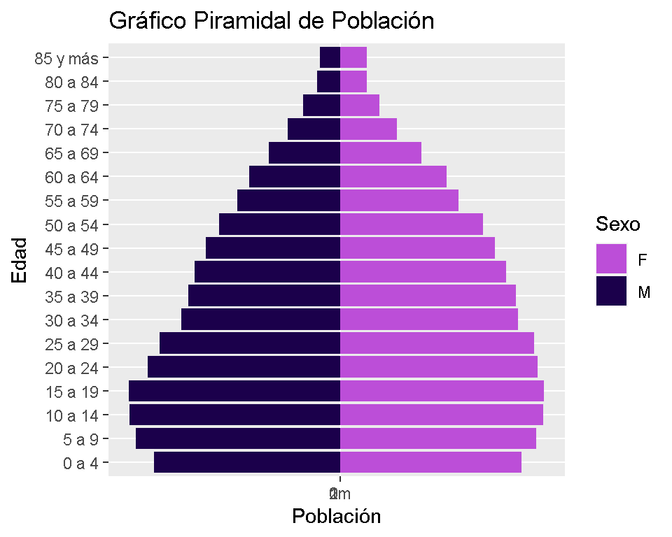

En el siguiente mapa se observa como se distribuye la población sobre la región:

[interactive chart not shown]

### Socioeconómicos

La población en terminos de la poblacioón economicamente activa esta descrita por:

- Porcentaje de población de 12 años y más económicamente activa: 52%
- Porcentaje de población de 12 años y más no económicamente activa: 28% `

### Educación

La educación de la zona metropolitana esta caracterizada por los siguientes estadísticos:

- Porcentaje de población de 15 años y más sin escolaridad:4%
- Porcentaje de población de 15 años y más con al menos un grado aprobado en primaria: 72%
- Porcentaje de población de 15 años y más con educación básica completa: 21%
- Porcentaje de población de 15 años y más con secundaria o equivalente incompleta:2%
- Porcentaje de población de 18 años y más con al menos un grado aprobado en educación media superior: 30%

### Salud

La situación de la afiliación a algún servico de salud es la siguiente:

- Porcentaje de población afiliada a servicios de salud: 70%
- Población sin afiliación a servicios de salud:146155

### Indicadores de desarrollo

Finalmente se presentan tres indicadores de desarrollo; los índices son: índice de Desarrollo Humano (IDH), Índice de Marginación (IM) e Índice de Rezago Social (IRS).

IDH es un indicador elaborado por el Programa de Naciones Unidas para el Desarrollo (PNUD), este busca medir la calidad de vida, así como el progreso socioeconómico de cada entidad y municipio; El cálculo del Índice de Desarrollo Humano se realiza a partir de las tres variables: esperanza de vida, educación e ingreso per cápita.

- Muy Alto - IDH mayor de 1.
- Alto - IDH entre 0.80 a 1.
- Medio - IDH entre 0.50 y 0.80.
- Bajo - IDH entre 0 y 0.50
- Muy Bajo - IDH menores a 0.
- El promedio del IDH en 2020 para la zona metropolitana es de 0.74 según datos del PNUD.

El IM es un índice construido por el consejo Nacional de Población (CONAPO). Este índice considera 4 dimensiones estructurales para su construcción: vivienda, ingreso, educación y distribución de la población. El indice se puede ubicar en 5 estratos designados por la ténica de estratificación de Dalenius-Hodges..

Por último, el IRS es construido por el Consejo Nacional de Evaluación de la Política de Desarrollo Social, CONEVAL, este índice incorpora indicadores de educación, de acceso a servicios de salud, de servicios básicos y tiene como finalidad ordenar los municipios según sus carencias sociales. Este índice, al igual que el IM, se clasifica en cinco estratos.

## Datos económicos.

Con base en la información de los subsectores de los 21 sectores principales de la clasificación del SCIAN, extraída de los Censos Económicos del INEGI durante el periodo de 1998-2018, se ha llevado a cabo la agrupación de los datos de cada municipio que pertenece a una zona metropolitana en cinco grandes sectores: Primarios, Construcción, Manufactura, Comercio y Servicios. Esta clasificación se basa en la metodología proporcionada por el INEGI. Se utilizaron las siguientes variables:

- Unidades económicas (UE) [número de unidades]
- Activiso fijos totales (AF) [miles de pesos a precios corrientes]
- Formación bruta de capital fijo (FB) [miles de pesos a precios corrientes]
- Producción bruta total (PB) [miles de pesos a precios corrientes]
- Personal ocupado total (PO) [número de personas]
- Total de remuneraciones (RE) [miles de pesos a precios corrientes]
- Valor agregado censal bruto (VA) [miles de pesos a precios corrientes]

Posteriormente, se replica la metodología utilizada por García y Carranco (2008) para estimar los coeficientes de participación relativa (PR), de localización de la actividad económica (QL), Hirschman-Herfindahl (HH) e Inverso de Hirschman-Herfindahl (IHH).

$PR_ij$=$X_ij/X_in$

$QL_ij$=$(X_ij⁄X_j )/(X_in⁄X_n)$

$HH_ij$=$X_ij/X_in - X_j/X_n$

$IHH_ij$=$1/(X_ij/X_in - X_j/X_n)$

Donde:

- $X_ij$= Variable económica del sector i en el municipio j
- $X_j$= Variable económica del total de los sectores en el municipio j
- $X_in$= Variable económica del sector i de la Zona Metropolitana del municipio j
- $X_n$= Variable económica del total de los sectores de la Zona Metropolitana del municipio j

### Cifras brutas

#### 1999

##### UE

| Clave | Municipio | Primarios | Construcción | Manufactura | Comercio | Servicios |
| --- | --- | --- | --- | --- | --- | --- |
| 17002 | Atlatlahucan | 0 | 0 | 15 | 176 | 38 |
| 17004 | Ayala | 21 | 0 | 123 | 705 | 127 |
| 17006 | Cuautla | 0 | 0 | 467 | 4,332 | 2,486 |
| 17026 | Tlayacapan | 0 | 0 | 55 | 239 | 12 |
| 17029 | Yautepec | 0 | 0 | 336 | 1,794 | 966 |
| 17030 | Yecapixtla | 0 | 0 | 121 | 397 | 78 |

##### AF

| Clave | Municipio | Primarios | Construcción | Manufactura | Comercio | Servicios |
| --- | --- | --- | --- | --- | --- | --- |
| 17002 | Atlatlahucan | 0 | 0 | 1,637 | 24,181 | 96,958 |
| 17004 | Ayala | 2,389 | 0 | 863,874 | 19,593 | 30,074 |
| 17006 | Cuautla | 2,830 | 1,418 | 1,013,092 | 292,250 | 984,948 |
| 17026 | Tlayacapan | 50 | 0 | 2,846 | 10,730 | 9,512 |
| 17029 | Yautepec | 3,151 | 101 | 68,043 | 78,671 | 1,073,876 |
| 17030 | Yecapixtla | 5,561 | 0 | 4,460 | 10,338 | 8,774 |

##### FB

| Clave | Municipio | Primarios | Construcción | Manufactura | Comercio | Servicios |
| --- | --- | --- | --- | --- | --- | --- |
| 17002 | Atlatlahucan | 0 | 0 | 140 | -650 | 616 |
| 17004 | Ayala | 15 | 0 | 207,260 | 238 | 533 |
| 17006 | Cuautla | 0 | -121 | 28,688 | 8,547 | 24,588 |
| 17026 | Tlayacapan | 0 | 0 | 59 | 105 | 198 |
| 17029 | Yautepec | 0 | 4 | 3,255 | 8,652 | 6,892 |
| 17030 | Yecapixtla | 0 | 0 | 245 | 91 | 169 |

##### PB

| Clave | Municipio | Primarios | Construcción | Manufactura | Comercio | Servicios |
| --- | --- | --- | --- | --- | --- | --- |
| 17002 | Atlatlahucan | 0 | 0 | 3,460 | 31,415 | 42,825 |
| 17004 | Ayala | 2,285 | 0 | 1,844,231 | 37,716 | 115,633 |
| 17006 | Cuautla | 245 | 1,748 | 1,335,393 | 701,409 | 1,054,577 |
| 17026 | Tlayacapan | 176 | 0 | 5,737 | 9,259 | 6,687 |
| 17029 | Yautepec | 11,763 | 260 | 192,765 | 128,439 | 222,718 |
| 17030 | Yecapixtla | 6,785 | 0 | 34,856 | 12,765 | 6,056 |

##### PO

| Clave | Municipio | Primarios | Construcción | Manufactura | Comercio | Servicios |
| --- | --- | --- | --- | --- | --- | --- |
| 17002 | Atlatlahucan | 0 | 0 | 63 | 448 | 402 |
| 17004 | Ayala | 98 | 0 | 1,221 | 1,188 | 1,822 |
| 17006 | Cuautla | 10 | 14 | 3,332 | 9,011 | 8,307 |
| 17026 | Tlayacapan | 3 | 0 | 146 | 390 | 255 |
| 17029 | Yautepec | 28 | 10 | 1,174 | 3,096 | 3,756 |
| 17030 | Yecapixtla | 1 | 0 | 287 | 591 | 200 |

##### RE

| Clave | Municipio | Primarios | Construcción | Manufactura | Comercio | Servicios |
| --- | --- | --- | --- | --- | --- | --- |
| 17002 | Atlatlahucan | 0 | 0 | 530 | 5,938 | 7,194 |
| 17004 | Ayala | 0 | 0 | 17,573 | 8,704 | 70,960 |
| 17006 | Cuautla | 31 | 145 | 130,358 | 109,014 | 183,706 |
| 17026 | Tlayacapan | 0 | 0 | 766 | 500 | 1,164 |
| 17029 | Yautepec | 775 | 96 | 18,736 | 18,406 | 86,749 |
| 17030 | Yecapixtla | 21 | 0 | 1,700 | 813 | 839 |

##### VA

| Clave | Municipio | Primarios | Construcción | Manufactura | Comercio | Servicios |
| --- | --- | --- | --- | --- | --- | --- |
| 17002 | Atlatlahucan | 0 | 0 | 1,123 | 16,585 | 21,464 |
| 17004 | Ayala | 1,762 | 0 | 263,670 | 31,363 | 89,611 |
| 17006 | Cuautla | 221 | -442 | 400,084 | 512,131 | 508,426 |
| 17026 | Tlayacapan | 105 | 0 | 2,532 | 7,859 | 3,059 |
| 17029 | Yautepec | 4,351 | 136 | 36,506 | 95,094 | 119,951 |
| 17030 | Yecapixtla | 4,864 | 0 | 7,759 | 10,185 | 2,381 |

#### 2004

##### UE

| Clave | Municipio | Primarios | Construcción | Manufactura | Comercio | Servicios |
| --- | --- | --- | --- | --- | --- | --- |
| 17002 | Atlatlahucan | 0 | 0 | 18 | 235 | 75 |
| 17004 | Ayala | 0 | 0 | 131 | 800 | 324 |
| 17006 | Cuautla | 0 | 0 | 619 | 5,190 | 3,211 |
| 17026 | Tlayacapan | 0 | 0 | 77 | 308 | 119 |
| 17029 | Yautepec | 0 | 0 | 329 | 1,905 | 1,132 |
| 17030 | Yecapixtla | 0 | 0 | 169 | 582 | 144 |

##### AF

| Clave | Municipio | Primarios | Construcción | Manufactura | Comercio | Servicios |
| --- | --- | --- | --- | --- | --- | --- |
| 17002 | Atlatlahucan | 0 | 3,997 | 3,862 | 43,165 | 32,728 |
| 17004 | Ayala | 826 | 191 | 1,207,753 | 58,423 | 68,231 |
| 17006 | Cuautla | 0 | 20,209 | 564,140 | 745,977 | 932,427 |
| 17026 | Tlayacapan | 0 | 0 | 4,716 | 21,685 | 36,972 |
| 17029 | Yautepec | 16,908 | 75 | 146,615 | 165,731 | 501,503 |
| 17030 | Yecapixtla | 0 | 69 | 70,035 | 35,370 | 34,076 |

##### FB

| Clave | Municipio | Primarios | Construcción | Manufactura | Comercio | Servicios |
| --- | --- | --- | --- | --- | --- | --- |
| 17002 | Atlatlahucan | 0 | 511 | 112 | 2,064 | 6,755 |
| 17004 | Ayala | 600 | 180 | 63,595 | 2,263 | -971 |
| 17006 | Cuautla | 0 | 2,936 | 46,956 | 19,021 | 20,921 |
| 17026 | Tlayacapan | 0 | 0 | 283 | 954 | 1,122 |
| 17029 | Yautepec | 985 | -5 | 35,970 | 5,702 | 84,259 |
| 17030 | Yecapixtla | 0 | 2 | 9,124 | 2,640 | 955 |

##### PB

| Clave | Municipio | Primarios | Construcción | Manufactura | Comercio | Servicios |
| --- | --- | --- | --- | --- | --- | --- |
| 17002 | Atlatlahucan | 0 | 16,457 | 5,624 | 61,077 | 137,199 |
| 17004 | Ayala | 868 | 30 | 3,372,978 | 133,759 | 269,750 |
| 17006 | Cuautla | 0 | 42,119 | 1,498,243 | 1,332,134 | 1,101,185 |
| 17026 | Tlayacapan | 0 | 0 | 7,410 | 24,667 | 19,182 |
| 17029 | Yautepec | 4,261 | 800 | 452,611 | 229,160 | 588,068 |
| 17030 | Yecapixtla | 0 | 21 | 1,652,488 | 29,496 | 31,740 |

##### PO

| Clave | Municipio | Primarios | Construcción | Manufactura | Comercio | Servicios |
| --- | --- | --- | --- | --- | --- | --- |
| 17002 | Atlatlahucan | 0 | 50 | 77 | 796 | 518 |
| 17004 | Ayala | 27 | 2 | 2,283 | 1,541 | 1,781 |
| 17006 | Cuautla | 0 | 215 | 3,331 | 12,820 | 10,938 |
| 17026 | Tlayacapan | 0 | 0 | 180 | 588 | 454 |
| 17029 | Yautepec | 49 | 13 | 1,252 | 3,851 | 5,187 |
| 17030 | Yecapixtla | 0 | 1 | 2,597 | 1,038 | 563 |

##### RE

| Clave | Municipio | Primarios | Construcción | Manufactura | Comercio | Servicios |
| --- | --- | --- | --- | --- | --- | --- |
| 17002 | Atlatlahucan | 0 | 1,697 | 758 | 18,564 | 22,640 |
| 17004 | Ayala | 93 | 0 | 21,557 | 21,258 | 146,720 |
| 17006 | Cuautla | 0 | 4,501 | 202,534 | 214,366 | 190,883 |
| 17026 | Tlayacapan | 0 | 0 | 847 | 2,143 | 3,097 |
| 17029 | Yautepec | 568 | 378 | 42,982 | 28,623 | 131,367 |
| 17030 | Yecapixtla | 0 | 0 | 100,565 | 2,834 | 6,486 |

##### VA

| Clave | Municipio | Primarios | Construcción | Manufactura | Comercio | Servicios |
| --- | --- | --- | --- | --- | --- | --- |
| 17002 | Atlatlahucan | 0 | 6,331 | 1,652 | 39,901 | 84,601 |
| 17004 | Ayala | 540 | 11 | 824,464 | 110,942 | 228,220 |
| 17006 | Cuautla | 0 | 15,900 | 458,685 | 981,342 | 573,544 |
| 17026 | Tlayacapan | 0 | 0 | 3,314 | 21,270 | 10,309 |
| 17029 | Yautepec | 2,258 | 528 | 143,490 | 165,676 | 321,458 |
| 17030 | Yecapixtla | 0 | 11 | 515,745 | 23,386 | 15,803 |

#### 2009

##### UE

| Clave | Municipio | Primarios | Construcción | Manufactura | Comercio | Servicios |
| --- | --- | --- | --- | --- | --- | --- |
| 17002 | Atlatlahucan | 0 | 0 | 27 | 265 | 72 |
| 17004 | Ayala | 56 | 0 | 153 | 978 | 508 |
| 17006 | Cuautla | 0 | 23 | 818 | 6,252 | 4,032 |
| 17026 | Tlayacapan | 0 | 0 | 84 | 415 | 151 |
| 17029 | Yautepec | 0 | 0 | 463 | 2,407 | 1,637 |
| 17030 | Yecapixtla | 0 | 0 | 234 | 682 | 267 |

##### AF

| Clave | Municipio | Primarios | Construcción | Manufactura | Comercio | Servicios |
| --- | --- | --- | --- | --- | --- | --- |
| 17002 | Atlatlahucan | 0 | 6,451 | 7,374 | 39,820 | 254,160 |
| 17004 | Ayala | 31,988 | 0 | 2,703,926 | 131,460 | 128,725 |
| 17006 | Cuautla | 8,842 | 29,430 | 624,275 | 1,147,065 | 1,885,322 |
| 17026 | Tlayacapan | 0 | 21 | 6,796 | 44,242 | 55,058 |
| 17029 | Yautepec | 5,233 | 970 | 201,821 | 317,027 | 572,716 |
| 17030 | Yecapixtla | 0 | 0 | 94,029 | 47,078 | 50,477 |

##### FB

| Clave | Municipio | Primarios | Construcción | Manufactura | Comercio | Servicios |
| --- | --- | --- | --- | --- | --- | --- |
| 17002 | Atlatlahucan | 0 | 0 | 29 | 528 | 44,249 |
| 17004 | Ayala | 846 | 0 | 96,529 | 1,303 | 7,543 |
| 17006 | Cuautla | 6,316 | 2,749 | 3,481 | 129,058 | 155,016 |
| 17026 | Tlayacapan | 0 | 0 | 192 | 322 | 142 |
| 17029 | Yautepec | 3 | 0 | 9,925 | 16,607 | 13,244 |
| 17030 | Yecapixtla | 0 | 0 | 820 | 1,629 | 874 |

##### PB

| Clave | Municipio | Primarios | Construcción | Manufactura | Comercio | Servicios |
| --- | --- | --- | --- | --- | --- | --- |
| 17002 | Atlatlahucan | 0 | 23,218 | 11,670 | 83,896 | 176,762 |
| 17004 | Ayala | 8,623 | 0 | 6,209,090 | 275,912 | 573,349 |
| 17006 | Cuautla | 2,547 | 91,987 | 2,222,107 | 2,038,502 | 2,174,217 |
| 17026 | Tlayacapan | 0 | 510 | 18,239 | 30,707 | 67,014 |
| 17029 | Yautepec | 3,605 | 6,046 | 606,146 | 464,863 | 554,616 |
| 17030 | Yecapixtla | 0 | 0 | 1,048,295 | 67,475 | 65,788 |

##### PO

| Clave | Municipio | Primarios | Construcción | Manufactura | Comercio | Servicios |
| --- | --- | --- | --- | --- | --- | --- |
| 17002 | Atlatlahucan | 0 | 84 | 117 | 812 | 1,849 |
| 17004 | Ayala | 315 | 0 | 3,142 | 2,246 | 2,734 |
| 17006 | Cuautla | 223 | 225 | 4,237 | 17,703 | 16,767 |
| 17026 | Tlayacapan | 0 | 8 | 257 | 872 | 941 |
| 17029 | Yautepec | 62 | 56 | 1,629 | 5,582 | 6,150 |
| 17030 | Yecapixtla | 0 | 0 | 2,410 | 1,503 | 1,018 |

##### RE

| Clave | Municipio | Primarios | Construcción | Manufactura | Comercio | Servicios |
| --- | --- | --- | --- | --- | --- | --- |
| 17002 | Atlatlahucan | 0 | 9,777 | 1,175 | 14,951 | 46,879 |
| 17004 | Ayala | 1,142 | 0 | 26,189 | 62,942 | 187,777 |
| 17006 | Cuautla | 1,367 | 5,051 | 266,420 | 289,937 | 336,924 |
| 17026 | Tlayacapan | 0 | 151 | 3,370 | 2,867 | 8,227 |
| 17029 | Yautepec | 1,038 | 1,172 | 53,930 | 63,820 | 104,652 |
| 17030 | Yecapixtla | 0 | 0 | 92,445 | 5,845 | 9,419 |

##### VA

| Clave | Municipio | Primarios | Construcción | Manufactura | Comercio | Servicios |
| --- | --- | --- | --- | --- | --- | --- |
| 17002 | Atlatlahucan | 0 | 10,369 | 5,103 | 65,415 | 47,379 |
| 17004 | Ayala | 6,223 | 0 | 1,532,504 | 227,819 | 414,789 |
| 17006 | Cuautla | 1,921 | 18,612 | 621,498 | 1,195,814 | 966,096 |
| 17026 | Tlayacapan | 0 | 312 | 7,011 | 22,745 | 31,438 |
| 17029 | Yautepec | 2,179 | 1,376 | 198,209 | 291,450 | 208,082 |
| 17030 | Yecapixtla | 0 | 0 | 392,742 | 28,587 | 25,842 |

#### 2014

##### UE

| Clave | Municipio | Primarios | Construcción | Manufactura | Comercio | Servicios |
| --- | --- | --- | --- | --- | --- | --- |
| 17002 | Atlatlahucan | 0 | 0 | 46 | 309 | 94 |
| 17004 | Ayala | 67 | 0 | 239 | 1,138 | 693 |
| 17006 | Cuautla | 0 | 6 | 898 | 6,265 | 5,011 |
| 17026 | Tlayacapan | 0 | 0 | 99 | 409 | 224 |
| 17029 | Yautepec | 0 | 0 | 467 | 2,306 | 1,816 |
| 17030 | Yecapixtla | 0 | 0 | 272 | 800 | 306 |

##### AF

| Clave | Municipio | Primarios | Construcción | Manufactura | Comercio | Servicios |
| --- | --- | --- | --- | --- | --- | --- |
| 17002 | Atlatlahucan | 0 | 0 | 4,758 | 20,393 | 12,995 |
| 17004 | Ayala | 62,492 | 0 | 2,812,760 | 229,160 | 90,489 |
| 17006 | Cuautla | 0 | 1,260 | 883,055 | 2,407,059 | 2,525,738 |
| 17026 | Tlayacapan | 0 | 0 | 6,052 | 64,917 | 43,965 |
| 17029 | Yautepec | 0 | 0 | 212,511 | 331,348 | 257,995 |
| 17030 | Yecapixtla | 0 | 0 | 299,014 | 62,703 | 61,453 |

##### FB

| Clave | Municipio | Primarios | Construcción | Manufactura | Comercio | Servicios |
| --- | --- | --- | --- | --- | --- | --- |
| 17002 | Atlatlahucan | 0 | 0 | 71 | 551 | 1,551 |
| 17004 | Ayala | 73 | 0 | 346,042 | 6,542 | 7,407 |
| 17006 | Cuautla | 0 | 49 | 72,656 | 73,360 | 180,188 |
| 17026 | Tlayacapan | 0 | 0 | 79 | 919 | 772 |
| 17029 | Yautepec | 0 | 0 | 12,072 | 15,350 | -2,668 |
| 17030 | Yecapixtla | 0 | 0 | 187,326 | 826 | 3,371 |

##### PB

| Clave | Municipio | Primarios | Construcción | Manufactura | Comercio | Servicios |
| --- | --- | --- | --- | --- | --- | --- |
| 17002 | Atlatlahucan | 0 | 0 | 9,961 | 58,770 | 13,473 |
| 17004 | Ayala | 12,522 | 0 | 4,956,524 | 264,634 | 908,824 |
| 17006 | Cuautla | 0 | 1,136 | 3,181,611 | 2,862,064 | 3,511,529 |
| 17026 | Tlayacapan | 0 | 0 | 30,664 | 41,947 | 44,516 |
| 17029 | Yautepec | 0 | 0 | 930,286 | 471,112 | 674,233 |
| 17030 | Yecapixtla | 0 | 0 | 1,323,890 | 120,966 | 53,768 |

##### PO

| Clave | Municipio | Primarios | Construcción | Manufactura | Comercio | Servicios |
| --- | --- | --- | --- | --- | --- | --- |
| 17002 | Atlatlahucan | 0 | 0 | 103 | 581 | 243 |
| 17004 | Ayala | 267 | 0 | 2,181 | 2,006 | 3,008 |
| 17006 | Cuautla | 0 | 13 | 3,929 | 15,900 | 17,327 |
| 17026 | Tlayacapan | 0 | 0 | 251 | 712 | 565 |
| 17029 | Yautepec | 0 | 0 | 1,492 | 4,463 | 5,377 |
| 17030 | Yecapixtla | 0 | 0 | 2,340 | 1,392 | 631 |

##### RE

| Clave | Municipio | Primarios | Construcción | Manufactura | Comercio | Servicios |
| --- | --- | --- | --- | --- | --- | --- |
| 17002 | Atlatlahucan | 0 | 0 | 1,467 | 4,823 | 5,594 |
| 17004 | Ayala | 1,066 | 0 | 23,435 | 69,929 | 268,681 |
| 17006 | Cuautla | 0 | 89 | 311,902 | 355,234 | 545,496 |
| 17026 | Tlayacapan | 0 | 0 | 3,154 | 2,892 | 5,581 |
| 17029 | Yautepec | 0 | 0 | 67,932 | 68,659 | 166,623 |
| 17030 | Yecapixtla | 0 | 0 | 167,467 | 10,443 | 7,504 |

##### VA

| Clave | Municipio | Primarios | Construcción | Manufactura | Comercio | Servicios |
| --- | --- | --- | --- | --- | --- | --- |
| 17002 | Atlatlahucan | 0 | 0 | 4,287 | 41,146 | 6,360 |
| 17004 | Ayala | 7,808 | 0 | 912,467 | 181,263 | 657,980 |
| 17006 | Cuautla | 0 | 314 | 810,349 | 1,903,074 | 1,840,870 |
| 17026 | Tlayacapan | 0 | 0 | 12,878 | 31,196 | 22,996 |
| 17029 | Yautepec | 0 | 0 | 190,023 | 334,690 | 387,387 |
| 17030 | Yecapixtla | 0 | 0 | 266,131 | 98,012 | 27,845 |

#### 2019

##### UE

| Clave | Municipio | Primarios | Construcción | Manufactura | Comercio | Servicios |
| --- | --- | --- | --- | --- | --- | --- |
| 17002 | Atlatlahucan | 0 | 3 | 88 | 502 | 352 |
| 17004 | Ayala | 117 | 1 | 300 | 1,340 | 933 |
| 17006 | Cuautla | 13 | 14 | 1,042 | 6,823 | 5,880 |
| 17026 | Tlayacapan | 0 | 0 | 99 | 518 | 326 |
| 17029 | Yautepec | 5 | 9 | 576 | 2,701 | 2,283 |
| 17030 | Yecapixtla | 0 | 2 | 397 | 1,091 | 819 |

##### AF

| Clave | Municipio | Primarios | Construcción | Manufactura | Comercio | Servicios |
| --- | --- | --- | --- | --- | --- | --- |
| 17002 | Atlatlahucan | 0 | 0 | 14,859 | 51,677 | 735,713 |
| 17004 | Ayala | 0 | 0 | 5,290,021 | 360,957 | 242,459 |
| 17006 | Cuautla | 0 | 131 | 1,752,771 | 2,954,615 | 3,073,600 |
| 17026 | Tlayacapan | 0 | 0 | 11,660 | 124,561 | 108,687 |
| 17029 | Yautepec | 0 | 102 | 362,230 | 588,363 | 980,339 |
| 17030 | Yecapixtla | 0 | 0 | 381,822 | 170,659 | 129,505 |

##### FB

| Clave | Municipio | Primarios | Construcción | Manufactura | Comercio | Servicios |
| --- | --- | --- | --- | --- | --- | --- |
| 17002 | Atlatlahucan | 0 | 0 | 75 | 217 | 3,222 |
| 17004 | Ayala | 0 | 0 | 15,217 | 8,396 | 1,433 |
| 17006 | Cuautla | 0 | 15 | 29,838 | 88,245 | 40,702 |
| 17026 | Tlayacapan | 0 | 0 | 41 | 6,675 | 31 |
| 17029 | Yautepec | 0 | -4 | 27,542 | 30,074 | 9,431 |
| 17030 | Yecapixtla | 0 | 0 | 10,986 | 6,144 | 4,392 |

##### PB

| Clave | Municipio | Primarios | Construcción | Manufactura | Comercio | Servicios |
| --- | --- | --- | --- | --- | --- | --- |
| 17002 | Atlatlahucan | 0 | 0 | 118,706 | 97,012 | 280,820 |
| 17004 | Ayala | 0 | 0 | 12,266,479 | 1,601,732 | 1,456,988 |
| 17006 | Cuautla | 0 | 2,007 | 8,899,693 | 4,552,961 | 5,391,866 |
| 17026 | Tlayacapan | 0 | 0 | 31,019 | 124,962 | 67,196 |
| 17029 | Yautepec | 0 | 565 | 678,365 | 920,091 | 1,148,477 |
| 17030 | Yecapixtla | 0 | 0 | 2,662,355 | 256,035 | 279,698 |

##### PO

| Clave | Municipio | Primarios | Construcción | Manufactura | Comercio | Servicios |
| --- | --- | --- | --- | --- | --- | --- |
| 17002 | Atlatlahucan | 0 | 0 | 160 | 775 | 1,494 |
| 17004 | Ayala | 0 | 0 | 3,184 | 2,939 | 7,418 |
| 17006 | Cuautla | 0 | 17 | 5,229 | 16,981 | 19,624 |
| 17026 | Tlayacapan | 0 | 0 | 233 | 887 | 744 |
| 17029 | Yautepec | 0 | 9 | 1,893 | 6,239 | 7,564 |
| 17030 | Yecapixtla | 0 | 0 | 3,219 | 2,080 | 1,381 |

##### RE

| Clave | Municipio | Primarios | Construcción | Manufactura | Comercio | Servicios |
| --- | --- | --- | --- | --- | --- | --- |
| 17002 | Atlatlahucan | 0 | 0 | 4,073 | 18,196 | 61,117 |
| 17004 | Ayala | 0 | 0 | 48,693 | 162,818 | 473,253 |
| 17006 | Cuautla | 0 | 251 | 497,504 | 456,811 | 775,736 |
| 17026 | Tlayacapan | 0 | 0 | 5,173 | 14,503 | 13,057 |
| 17029 | Yautepec | 0 | 126 | 91,701 | 156,397 | 332,090 |
| 17030 | Yecapixtla | 0 | 0 | 265,398 | 30,417 | 23,356 |

##### VA

| Clave | Municipio | Primarios | Construcción | Manufactura | Comercio | Servicios |
| --- | --- | --- | --- | --- | --- | --- |
| 17002 | Atlatlahucan | 0 | 0 | 34,935 | 77,482 | 134,501 |
| 17004 | Ayala | 0 | 0 | 1,250,102 | 1,018,928 | 1,012,926 |
| 17006 | Cuautla | 0 | 899 | 3,901,522 | 3,355,164 | 2,232,720 |
| 17026 | Tlayacapan | 0 | 0 | 13,687 | 82,069 | 33,582 |
| 17029 | Yautepec | 0 | 227 | 240,582 | 644,230 | 689,888 |
| 17030 | Yecapixtla | 0 | 0 | 935,224 | 196,173 | 113,838 |

### Coeficientes de localización (QL)

#### 1999

##### UE

| Clave | Municipio | Primarios | Construcción | Manufactura | Comercio | Servicios |
| --- | --- | --- | --- | --- | --- | --- |
| 17002 | Atlatlahucan | 0.0000 | 0.0000 | 0.5904 | 1.4566 | 0.4703 |
| 17004 | Ayala | 8.1013 | 0.0000 | 1.1358 | 1.3690 | 0.3688 |
| 17006 | Cuautla | 0.0000 | 0.0000 | 0.5778 | 1.1270 | 0.9672 |
| 17026 | Tlayacapan | 0.0000 | 0.0000 | 1.6199 | 1.4803 | 0.1111 |
| 17029 | Yautepec | 0.0000 | 0.0000 | 0.9781 | 1.0982 | 0.8843 |
| 17030 | Yecapixtla | 0.0000 | 0.0000 | 1.8298 | 1.2625 | 0.3709 |

##### AF

| Clave | Municipio | Primarios | Construcción | Manufactura | Comercio | Servicios |
| --- | --- | --- | --- | --- | --- | --- |
| 17002 | Atlatlahucan | 0.0000 | 0.0000 | 0.0392 | 2.5932 | 1.4510 |
| 17004 | Ayala | 0.1072 | 0.0000 | 2.7720 | 0.2817 | 0.0603 |
| 17006 | Cuautla | 0.0507 | 0.0406 | 1.2977 | 1.6770 | 0.7887 |
| 17026 | Tlayacapan | 0.0888 | 0.0000 | 0.3615 | 6.1059 | 0.7554 |
| 17029 | Yautepec | 0.1058 | 0.0054 | 0.1634 | 0.8464 | 1.6123 |
| 17030 | Yecapixtla | 7.8431 | 0.0000 | 0.4499 | 4.6723 | 0.5534 |

##### FB

[output not shown]

##### PB

| Clave | Municipio | Primarios | Construcción | Manufactura | Comercio | Servicios |
| --- | --- | --- | --- | --- | --- | --- |
| 17002 | Atlatlahucan | 0.0000 | 0.0000 | 0.0900 | 2.8934 | 1.7257 |
| 17004 | Ayala | 0.1145 | 0.0000 | 1.8637 | 0.1350 | 0.1810 |
| 17006 | Cuautla | 0.0079 | 0.0157 | 0.8724 | 1.6227 | 1.0674 |
| 17026 | Tlayacapan | 0.8068 | 0.0000 | 0.5304 | 3.0313 | 0.9578 |
| 17029 | Yautepec | 2.1203 | 0.0130 | 0.7007 | 1.6533 | 1.2543 |
| 17030 | Yecapixtla | 11.2454 | 0.0000 | 1.1651 | 1.5109 | 0.3136 |

##### PO

| Clave | Municipio | Primarios | Construcción | Manufactura | Comercio | Servicios |
| --- | --- | --- | --- | --- | --- | --- |
| 17002 | Atlatlahucan | 0.0000 | 0.0000 | 0.2235 | 1.8911 | 1.1924 |
| 17004 | Ayala | 2.5521 | 0.0000 | 0.9137 | 1.0577 | 1.1398 |
| 17006 | Cuautla | 0.0545 | 0.0126 | 0.5221 | 1.6798 | 1.0881 |
| 17026 | Tlayacapan | 0.4260 | 0.0000 | 0.5957 | 1.8930 | 0.8697 |
| 17029 | Yautepec | 0.3914 | 0.0231 | 0.4716 | 1.4797 | 1.2613 |
| 17030 | Yecapixtla | 0.1045 | 0.0000 | 0.8617 | 2.1110 | 0.5020 |

##### RE

| Clave | Municipio | Primarios | Construcción | Manufactura | Comercio | Servicios |
| --- | --- | --- | --- | --- | --- | --- |
| 17002 | Atlatlahucan | 0.0000 | 0.0000 | 0.1049 | 3.0608 | 1.1670 |
| 17004 | Ayala | 0.0000 | 0.0000 | 0.4888 | 0.6304 | 1.6173 |
| 17006 | Cuautla | 0.0065 | 0.0133 | 0.8330 | 1.8138 | 0.9619 |
| 17026 | Tlayacapan | 0.0000 | 0.0000 | 0.8526 | 1.4490 | 1.0616 |
| 17029 | Yautepec | 0.5478 | 0.0299 | 0.4062 | 1.0389 | 1.5410 |
| 17030 | Yecapixtla | 0.5490 | 0.0000 | 1.3631 | 1.6974 | 0.5513 |

##### VA

| Clave | Municipio | Primarios | Construcción | Manufactura | Comercio | Servicios |
| --- | --- | --- | --- | --- | --- | --- |
| 17002 | Atlatlahucan | 0.0000 | 0.0000 | 0.0778 | 1.9008 | 1.4619 |
| 17004 | Ayala | 0.3878 | 0.0000 | 1.8520 | 0.3644 | 0.6187 |
| 17006 | Cuautla | 0.0132 | -0.0140 | 0.7645 | 1.6187 | 0.9550 |
| 17026 | Tlayacapan | 0.6588 | 0.0000 | 0.5070 | 2.6030 | 0.6021 |
| 17029 | Yautepec | 1.4453 | 0.0239 | 0.3870 | 1.6674 | 1.2499 |
| 17030 | Yecapixtla | 16.4235 | 0.0000 | 0.8360 | 1.8153 | 0.2522 |

#### 2004

##### UE

| Clave | Municipio | Primarios | Construcción | Manufactura | Comercio | Servicios |
| --- | --- | --- | --- | --- | --- | --- |
| 17002 | Atlatlahucan | 0.0000 | 0.0000 | 0.5614 | 1.3269 | 0.6431 |
| 17004 | Ayala | 0.0000 | 0.0000 | 1.0679 | 1.1806 | 0.7261 |
| 17006 | Cuautla | 0.0000 | 0.0000 | 0.7021 | 1.0657 | 1.0012 |
| 17026 | Tlayacapan | 0.0000 | 0.0000 | 1.5630 | 1.1318 | 0.6640 |
| 17029 | Yautepec | 0.0000 | 0.0000 | 1.0000 | 1.0482 | 0.9458 |
| 17030 | Yecapixtla | 0.0000 | 0.0000 | 1.9318 | 1.2044 | 0.4525 |

##### AF

| Clave | Municipio | Primarios | Construcción | Manufactura | Comercio | Servicios |
| --- | --- | --- | --- | --- | --- | --- |
| 17002 | Atlatlahucan | 0.0000 | 4.3438 | 0.1259 | 5.7306 | 0.7572 |
| 17004 | Ayala | 0.0372 | 0.0130 | 2.4687 | 0.4864 | 0.0990 |
| 17006 | Cuautla | 0.0000 | 0.8129 | 0.6805 | 3.6657 | 0.7985 |
| 17026 | Tlayacapan | 0.0000 | 0.0000 | 0.2031 | 3.8047 | 1.1304 |
| 17029 | Yautepec | 1.2237 | 0.0082 | 0.4817 | 2.2180 | 1.1696 |
| 17030 | Yecapixtla | 0.0000 | 0.0450 | 1.3699 | 2.8182 | 0.4731 |

##### FB

[output not shown]

##### PB

| Clave | Municipio | Primarios | Construcción | Manufactura | Comercio | Servicios |
| --- | --- | --- | --- | --- | --- | --- |
| 17002 | Atlatlahucan | 0.0000 | 2.3595 | 0.0553 | 2.0179 | 1.7349 |
| 17004 | Ayala | 0.0225 | 0.0003 | 1.9332 | 0.2578 | 0.1990 |
| 17006 | Cuautla | 0.0000 | 0.3349 | 0.8163 | 2.4407 | 0.7722 |
| 17026 | Tlayacapan | 0.0000 | 0.0000 | 0.3130 | 3.5035 | 1.0427 |
| 17029 | Yautepec | 0.3271 | 0.0198 | 0.7686 | 1.3086 | 1.2853 |
| 17030 | Yecapixtla | 0.0000 | 0.0004 | 2.0876 | 0.1253 | 0.0516 |

##### PO

| Clave | Municipio | Primarios | Construcción | Manufactura | Comercio | Servicios |
| --- | --- | --- | --- | --- | --- | --- |
| 17002 | Atlatlahucan | 0.0000 | 0.7501 | 0.2028 | 1.8894 | 0.9226 |
| 17004 | Ayala | 0.5798 | 0.0077 | 1.5379 | 0.9355 | 0.8113 |
| 17006 | Cuautla | 0.0000 | 0.1702 | 0.4630 | 1.6060 | 1.0281 |
| 17026 | Tlayacapan | 0.0000 | 0.0000 | 0.5591 | 1.6458 | 0.9535 |
| 17029 | Yautepec | 0.5727 | 0.0271 | 0.4590 | 1.2724 | 1.2860 |
| 17030 | Yecapixtla | 0.0000 | 0.0051 | 2.3474 | 0.8455 | 0.3441 |

##### RE

| Clave | Municipio | Primarios | Construcción | Manufactura | Comercio | Servicios |
| --- | --- | --- | --- | --- | --- | --- |
| 17002 | Atlatlahucan | 0.0000 | 1.4885 | 0.0495 | 2.7198 | 1.1339 |
| 17004 | Ayala | 0.0515 | 0.0000 | 0.3241 | 0.7171 | 1.6919 |
| 17006 | Cuautla | 0.0000 | 0.2815 | 0.9432 | 2.2394 | 0.6817 |
| 17026 | Tlayacapan | 0.0000 | 0.0000 | 0.3968 | 2.2519 | 1.1126 |
| 17029 | Yautepec | 0.2926 | 0.0710 | 0.6010 | 0.8978 | 1.4087 |
| 17030 | Yecapixtla | 0.0000 | 0.0000 | 2.6095 | 0.1650 | 0.1291 |

##### VA

| Clave | Municipio | Primarios | Construcción | Manufactura | Comercio | Servicios |
| --- | --- | --- | --- | --- | --- | --- |
| 17002 | Atlatlahucan | 0.0000 | 2.1385 | 0.0384 | 1.5288 | 1.4529 |
| 17004 | Ayala | 0.0288 | 0.0004 | 2.1789 | 0.4837 | 0.4460 |
| 17006 | Cuautla | 0.0000 | 0.3506 | 0.6954 | 2.4545 | 0.6430 |
| 17026 | Tlayacapan | 0.0000 | 0.0000 | 0.2922 | 3.0943 | 0.6722 |
| 17029 | Yautepec | 0.2213 | 0.0373 | 0.6970 | 1.3277 | 1.1547 |
| 17030 | Yecapixtla | 0.0000 | 0.0009 | 2.8593 | 0.2139 | 0.0648 |

#### 2009

##### UE

| Clave | Municipio | Primarios | Construcción | Manufactura | Comercio | Servicios |
| --- | --- | --- | --- | --- | --- | --- |
| 17002 | Atlatlahucan | 0.0000 | 0.0000 | 0.7202 | 1.4318 | 0.5190 |
| 17004 | Ayala | 22.5845 | 0.0000 | 0.8764 | 1.1348 | 0.7864 |
| 17006 | Cuautla | 0.0000 | 0.3474 | 0.7139 | 1.1052 | 0.9510 |
| 17026 | Tlayacapan | 0.0000 | 0.0000 | 1.2547 | 1.2557 | 0.6095 |
| 17029 | Yautepec | 0.0000 | 0.0000 | 0.9974 | 1.0503 | 0.9530 |
| 17030 | Yecapixtla | 0.0000 | 0.0000 | 1.9204 | 1.1338 | 0.5922 |

##### AF

| Clave | Municipio | Primarios | Construcción | Manufactura | Comercio | Servicios |
| --- | --- | --- | --- | --- | --- | --- |
| 17002 | Atlatlahucan | 0.0000 | 1.3198 | 0.0896 | 1.3757 | 1.3678 |
| 17004 | Ayala | 0.5633 | 0.0000 | 3.3743 | 0.4666 | 0.0712 |
| 17006 | Cuautla | 0.1263 | 0.5016 | 0.6317 | 3.3013 | 0.8452 |
| 17026 | Tlayacapan | 0.0000 | 0.0125 | 0.2394 | 4.4336 | 0.8595 |
| 17029 | Yautepec | 0.2515 | 0.0556 | 0.6874 | 3.0711 | 0.8642 |
| 17030 | Yecapixtla | 0.0000 | 0.0000 | 1.8350 | 2.6132 | 0.4365 |

##### FB

[output not shown]

##### PB

| Clave | Municipio | Primarios | Construcción | Manufactura | Comercio | Servicios |
| --- | --- | --- | --- | --- | --- | --- |
| 17002 | Atlatlahucan | 0.0000 | 1.8583 | 0.0814 | 2.7133 | 1.7103 |
| 17004 | Ayala | 0.0674 | 0.0000 | 1.8104 | 0.3732 | 0.2320 |
| 17006 | Cuautla | 0.0215 | 0.3333 | 0.7013 | 2.9841 | 0.9522 |
| 17026 | Tlayacapan | 0.0000 | 0.1036 | 0.3227 | 2.5200 | 1.6454 |
| 17029 | Yautepec | 0.1217 | 0.0875 | 0.7638 | 2.7171 | 0.9699 |
| 17030 | Yecapixtla | 0.0000 | 0.0000 | 1.8282 | 0.5458 | 0.1592 |

##### PO

| Clave | Municipio | Primarios | Construcción | Manufactura | Comercio | Servicios |
| --- | --- | --- | --- | --- | --- | --- |
| 17002 | Atlatlahucan | 0.0000 | 0.7385 | 0.1719 | 0.9979 | 1.4988 |
| 17004 | Ayala | 5.2297 | 0.0000 | 1.5664 | 0.9363 | 0.7518 |
| 17006 | Cuautla | 0.7978 | 0.1446 | 0.4551 | 1.5902 | 0.9935 |
| 17026 | Tlayacapan | 0.0000 | 0.0969 | 0.5202 | 1.4759 | 1.0506 |
| 17029 | Yautepec | 0.6443 | 0.1045 | 0.5083 | 1.4565 | 1.0585 |
| 17030 | Yecapixtla | 0.0000 | 0.0000 | 2.0557 | 1.0720 | 0.4790 |

##### RE

| Clave | Municipio | Primarios | Construcción | Manufactura | Comercio | Servicios |
| --- | --- | --- | --- | --- | --- | --- |
| 17002 | Atlatlahucan | 0.0000 | 3.5871 | 0.0490 | 1.6115 | 1.3096 |
| 17004 | Ayala | 0.3031 | 0.0000 | 0.2857 | 1.7758 | 1.3731 |
| 17006 | Cuautla | 0.1121 | 0.1499 | 0.8982 | 2.5281 | 0.7614 |
| 17026 | Tlayacapan | 0.0000 | 0.2759 | 0.6994 | 1.5389 | 1.1445 |
| 17029 | Yautepec | 0.3411 | 0.1393 | 0.7283 | 2.2290 | 0.9473 |
| 17030 | Yecapixtla | 0.0000 | 0.0000 | 2.6033 | 0.4257 | 0.1778 |

##### VA

| Clave | Municipio | Primarios | Construcción | Manufactura | Comercio | Servicios |
| --- | --- | --- | --- | --- | --- | --- |
| 17002 | Atlatlahucan | 0.0000 | 2.7309 | 0.1123 | 3.5358 | 0.8331 |
| 17004 | Ayala | 0.1005 | 0.0000 | 1.9823 | 0.7241 | 0.4289 |
| 17006 | Cuautla | 0.0241 | 0.2242 | 0.6254 | 2.9568 | 0.7771 |
| 17026 | Tlayacapan | 0.0000 | 0.1714 | 0.3216 | 2.5638 | 1.1529 |
| 17029 | Yautepec | 0.1095 | 0.0663 | 0.7974 | 2.8813 | 0.6692 |
| 17030 | Yecapixtla | 0.0000 | 0.0000 | 2.4781 | 0.4432 | 0.1303 |

#### 2014

##### UE

| Clave | Municipio | Primarios | Construcción | Manufactura | Comercio | Servicios |
| --- | --- | --- | --- | --- | --- | --- |
| 17002 | Atlatlahucan | 0.0000 | 0.0000 | 1.0432 | 1.4099 | 0.5144 |
| 17004 | Ayala | 18.5548 | 0.0000 | 1.1388 | 1.0910 | 0.7968 |
| 17006 | Cuautla | 0.0000 | 0.0987 | 0.7507 | 1.0538 | 1.0109 |
| 17026 | Tlayacapan | 0.0000 | 0.0000 | 1.3771 | 1.1447 | 0.7519 |
| 17029 | Yautepec | 0.0000 | 0.0000 | 1.0362 | 1.0295 | 0.9723 |
| 17030 | Yecapixtla | 0.0000 | 0.0000 | 2.0098 | 1.1894 | 0.5456 |

##### AF

| Clave | Municipio | Primarios | Construcción | Manufactura | Comercio | Servicios |
| --- | --- | --- | --- | --- | --- | --- |
| 17002 | Atlatlahucan | 0.0000 | 0.0000 | 0.4562 | 4.8634 | 0.5769 |
| 17004 | Ayala | 1.4925 | 0.0000 | 3.2199 | 0.6525 | 0.0480 |
| 17006 | Cuautla | 0.0000 | 0.0166 | 0.5552 | 3.7643 | 0.7353 |
| 17026 | Tlayacapan | 0.0000 | 0.0000 | 0.1926 | 5.1383 | 0.6478 |
| 17029 | Yautepec | 0.0000 | 0.0000 | 0.9693 | 3.7592 | 0.5449 |
| 17030 | Yecapixtla | 0.0000 | 0.0000 | 2.5843 | 1.3480 | 0.2459 |

##### FB

[output not shown]

##### PB

| Clave | Municipio | Primarios | Construcción | Manufactura | Comercio | Servicios |
| --- | --- | --- | --- | --- | --- | --- |
| 17002 | Atlatlahucan | 0.0000 | 0.0000 | 0.2480 | 5.9959 | 0.4602 |
| 17004 | Ayala | 0.3615 | 0.0000 | 1.6512 | 0.3613 | 0.4154 |
| 17006 | Cuautla | 0.0000 | 0.0039 | 0.6813 | 2.5118 | 1.0317 |
| 17026 | Tlayacapan | 0.0000 | 0.0000 | 0.5357 | 3.0035 | 1.0671 |
| 17029 | Yautepec | 0.0000 | 0.0000 | 0.9171 | 1.9035 | 0.9120 |
| 17030 | Yecapixtla | 0.0000 | 0.0000 | 1.8077 | 0.6770 | 0.1007 |

##### PO

| Clave | Municipio | Primarios | Construcción | Manufactura | Comercio | Servicios |
| --- | --- | --- | --- | --- | --- | --- |
| 17002 | Atlatlahucan | 0.0000 | 0.0000 | 0.4599 | 2.1976 | 0.5968 |
| 17004 | Ayala | 8.7929 | 0.0000 | 1.2097 | 0.9426 | 0.9178 |
| 17006 | Cuautla | 0.0000 | 0.0117 | 0.4375 | 1.5000 | 1.0613 |
| 17026 | Tlayacapan | 0.0000 | 0.0000 | 0.6799 | 1.6339 | 0.8419 |
| 17029 | Yautepec | 0.0000 | 0.0000 | 0.5449 | 1.3810 | 1.0803 |
| 17030 | Yecapixtla | 0.0000 | 0.0000 | 2.2197 | 1.1187 | 0.3293 |

##### RE

| Clave | Municipio | Primarios | Construcción | Manufactura | Comercio | Servicios |
| --- | --- | --- | --- | --- | --- | --- |
| 17002 | Atlatlahucan | 0.0000 | 0.0000 | 0.3616 | 2.9527 | 0.9777 |
| 17004 | Ayala | 0.1803 | 0.0000 | 0.1890 | 1.4011 | 1.5369 |
| 17006 | Cuautla | 0.0000 | 0.0031 | 0.7534 | 2.1312 | 0.9343 |
| 17026 | Tlayacapan | 0.0000 | 0.0000 | 0.7946 | 1.8097 | 0.9970 |
| 17029 | Yautepec | 0.0000 | 0.0000 | 0.6563 | 1.6475 | 1.1414 |
| 17030 | Yecapixtla | 0.0000 | 0.0000 | 2.6457 | 0.4098 | 0.0841 |

##### VA

| Clave | Municipio | Primarios | Construcción | Manufactura | Comercio | Servicios |
| --- | --- | --- | --- | --- | --- | --- |
| 17002 | Atlatlahucan | 0.0000 | 0.0000 | 0.2461 | 4.5020 | 0.2684 |
| 17004 | Ayala | 0.5778 | 0.0000 | 1.5421 | 0.5838 | 0.8173 |
| 17006 | Cuautla | 0.0000 | 0.0031 | 0.5291 | 2.3679 | 0.8834 |
| 17026 | Tlayacapan | 0.0000 | 0.0000 | 0.5710 | 2.6358 | 0.7494 |
| 17029 | Yautepec | 0.0000 | 0.0000 | 0.6195 | 2.0795 | 0.9283 |
| 17030 | Yecapixtla | 0.0000 | 0.0000 | 2.0189 | 1.4170 | 0.1553 |

#### 2019

##### UE

| Clave | Municipio | Primarios | Construcción | Manufactura | Comercio | Servicios |
| --- | --- | --- | --- | --- | --- | --- |
| 17002 | Atlatlahucan | 0.0000 | 0.6120 | 0.9420 | 1.1326 | 0.8774 |
| 17004 | Ayala | 18.2995 | 0.0716 | 1.1278 | 1.0617 | 0.8166 |
| 17006 | Cuautla | 0.3973 | 0.1960 | 0.7654 | 1.0563 | 1.0056 |
| 17026 | Tlayacapan | 0.0000 | 0.0000 | 1.0620 | 1.1712 | 0.8143 |
| 17029 | Yautepec | 0.3775 | 0.3113 | 1.0454 | 1.0331 | 0.9647 |
| 17030 | Yecapixtla | 0.0000 | 0.1670 | 1.7393 | 1.0074 | 0.8355 |

##### AF

| Clave | Municipio | Primarios | Construcción | Manufactura | Comercio | Servicios |
| --- | --- | --- | --- | --- | --- | --- |
| 17002 | Atlatlahucan | 0.0000 | 0.0000 | 0.0654 | 0.3291 | 1.8592 |
| 17004 | Ayala | 0.0000 | 0.0000 | 3.1685 | 0.3129 | 0.0834 |
| 17006 | Cuautla | 0.0000 | 0.0014 | 0.7952 | 1.9397 | 0.8008 |
| 17026 | Tlayacapan | 0.0000 | 0.0000 | 0.1681 | 2.5981 | 0.8997 |
| 17029 | Yautepec | 0.0000 | 0.0043 | 0.6622 | 1.5565 | 1.0292 |
| 17030 | Yecapixtla | 0.0000 | 0.0000 | 1.9763 | 1.2783 | 0.3850 |

##### FB

[output not shown]

##### PB

| Clave | Municipio | Primarios | Construcción | Manufactura | Comercio | Servicios |
| --- | --- | --- | --- | --- | --- | --- |
| 17002 | Atlatlahucan | 0.0000 | 0.0000 | 0.4789 | 1.3979 | 1.7232 |
| 17004 | Ayala | 0.0000 | 0.0000 | 1.6034 | 0.7478 | 0.2897 |
| 17006 | Cuautla | 0.0000 | 0.0037 | 0.9459 | 1.7285 | 0.8717 |
| 17026 | Tlayacapan | 0.0000 | 0.0000 | 0.2784 | 4.0063 | 0.9174 |
| 17029 | Yautepec | 0.0000 | 0.0072 | 0.4946 | 2.3961 | 1.2736 |
| 17030 | Yecapixtla | 0.0000 | 0.0000 | 1.6676 | 0.5728 | 0.2665 |

##### PO

| Clave | Municipio | Primarios | Construcción | Manufactura | Comercio | Servicios |
| --- | --- | --- | --- | --- | --- | --- |
| 17002 | Atlatlahucan | 0.0000 | 0.0000 | 0.2682 | 1.2349 | 1.3276 |
| 17004 | Ayala | 0.0000 | 0.0000 | 0.9573 | 0.8401 | 1.1824 |
| 17006 | Cuautla | 0.0000 | 0.0141 | 0.5087 | 1.5705 | 1.0121 |
| 17026 | Tlayacapan | 0.0000 | 0.0000 | 0.5089 | 1.8418 | 0.8615 |
| 17029 | Yautepec | 0.0000 | 0.0200 | 0.4907 | 1.5376 | 1.0395 |
| 17030 | Yecapixtla | 0.0000 | 0.0000 | 1.9618 | 1.2052 | 0.4462 |

##### RE

| Clave | Municipio | Primarios | Construcción | Manufactura | Comercio | Servicios |
| --- | --- | --- | --- | --- | --- | --- |
| 17002 | Atlatlahucan | 0.0000 | 0.0000 | 0.1351 | 1.6130 | 1.5304 |
| 17004 | Ayala | 0.0000 | 0.0000 | 0.1967 | 1.7575 | 1.4431 |
| 17006 | Cuautla | 0.0000 | 0.0069 | 0.7953 | 1.9515 | 0.9361 |
| 17026 | Tlayacapan | 0.0000 | 0.0000 | 0.4371 | 3.2750 | 0.8329 |
| 17029 | Yautepec | 0.0000 | 0.0104 | 0.4371 | 1.9921 | 1.1949 |
| 17030 | Yecapixtla | 0.0000 | 0.0000 | 2.2999 | 0.7044 | 0.1528 |

##### VA

| Clave | Municipio | Primarios | Construcción | Manufactura | Comercio | Servicios |
| --- | --- | --- | --- | --- | --- | --- |
| 17002 | Atlatlahucan | 0.0000 | 0.0000 | 0.4133 | 1.4210 | 1.3285 |
| 17004 | Ayala | 0.0000 | 0.0000 | 1.1127 | 1.4059 | 0.7527 |
| 17006 | Cuautla | 0.0000 | 0.0042 | 1.2009 | 1.6010 | 0.5738 |
| 17026 | Tlayacapan | 0.0000 | 0.0000 | 0.3091 | 2.8735 | 0.6333 |
| 17029 | Yautepec | 0.0000 | 0.0064 | 0.4462 | 1.8524 | 1.0684 |
| 17030 | Yecapixtla | 0.0000 | 0.0000 | 2.1939 | 0.7134 | 0.2230 |

### Participación Relativa (PR)

#### 1999

##### UE

| Clave | Municipio | Primarios | Construcción | Manufactura | Comercio | Servicios |
| --- | --- | --- | --- | --- | --- | --- |
| 17002 | Atlatlahucan | 0.0000 | 0.0000 | 0.0001 | 0.0002 | 0.0001 |
| 17004 | Ayala | 0.0042 | 0.0000 | 0.0006 | 0.0007 | 0.0002 |
| 17006 | Cuautla | 0.0000 | 0.0000 | 0.0023 | 0.0044 | 0.0038 |
| 17026 | Tlayacapan | 0.0000 | 0.0000 | 0.0003 | 0.0002 | 0.0000 |
| 17029 | Yautepec | 0.0000 | 0.0000 | 0.0016 | 0.0018 | 0.0015 |
| 17030 | Yecapixtla | 0.0000 | 0.0000 | 0.0006 | 0.0004 | 0.0001 |

##### AF

| Clave | Municipio | Primarios | Construcción | Manufactura | Comercio | Servicios |
| --- | --- | --- | --- | --- | --- | --- |
| 17002 | Atlatlahucan | 0e+00 | 0.0000 | 0.0000 | 0.0002 | 1e-04 |
| 17004 | Ayala | 0e+00 | 0.0000 | 0.0012 | 0.0001 | 0e+00 |
| 17006 | Cuautla | 1e-04 | 0.0000 | 0.0014 | 0.0018 | 9e-04 |
| 17026 | Tlayacapan | 0e+00 | 0.0000 | 0.0000 | 0.0001 | 0e+00 |
| 17029 | Yautepec | 1e-04 | 0.0000 | 0.0001 | 0.0005 | 9e-04 |
| 17030 | Yecapixtla | 1e-04 | 0.0000 | 0.0000 | 0.0001 | 0e+00 |

##### FB

[output not shown]

##### PB

| Clave | Municipio | Primarios | Construcción | Manufactura | Comercio | Servicios |
| --- | --- | --- | --- | --- | --- | --- |
| 17002 | Atlatlahucan | 0e+00 | 0.0000 | 0.0000 | 0.0001 | 0e+00 |
| 17004 | Ayala | 1e-04 | 0.0000 | 0.0012 | 0.0001 | 1e-04 |
| 17006 | Cuautla | 0e+00 | 0.0000 | 0.0008 | 0.0016 | 1e-03 |
| 17026 | Tlayacapan | 0e+00 | 0.0000 | 0.0000 | 0.0000 | 0e+00 |
| 17029 | Yautepec | 4e-04 | 0.0000 | 0.0001 | 0.0003 | 2e-04 |
| 17030 | Yecapixtla | 2e-04 | 0.0000 | 0.0000 | 0.0000 | 0e+00 |

##### PO

| Clave | Municipio | Primarios | Construcción | Manufactura | Comercio | Servicios |
| --- | --- | --- | --- | --- | --- | --- |
| 17002 | Atlatlahucan | 0e+00 | 0.0000 | 0e+00 | 0.0002 | 1e-04 |
| 17004 | Ayala | 1e-03 | 0.0000 | 4e-04 | 0.0004 | 4e-04 |
| 17006 | Cuautla | 1e-04 | 0.0000 | 1e-03 | 0.0031 | 2e-03 |
| 17026 | Tlayacapan | 0e+00 | 0.0000 | 0e+00 | 0.0001 | 1e-04 |
| 17029 | Yautepec | 3e-04 | 0.0000 | 3e-04 | 0.0011 | 9e-04 |
| 17030 | Yecapixtla | 0e+00 | 0.0000 | 1e-04 | 0.0002 | 0e+00 |

##### RE

| Clave | Municipio | Primarios | Construcción | Manufactura | Comercio | Servicios |
| --- | --- | --- | --- | --- | --- | --- |
| 17002 | Atlatlahucan | 0e+00 | 0.0000 | 0e+00 | 0.0001 | 0e+00 |
| 17004 | Ayala | 0e+00 | 0.0000 | 1e-04 | 0.0001 | 3e-04 |
| 17006 | Cuautla | 0e+00 | 0.0000 | 7e-04 | 0.0016 | 9e-04 |
| 17026 | Tlayacapan | 0e+00 | 0.0000 | 0e+00 | 0.0000 | 0e+00 |
| 17029 | Yautepec | 1e-04 | 0.0000 | 1e-04 | 0.0003 | 4e-04 |
| 17030 | Yecapixtla | 0e+00 | 0.0000 | 0e+00 | 0.0000 | 0e+00 |

##### VA

| Clave | Municipio | Primarios | Construcción | Manufactura | Comercio | Servicios |
| --- | --- | --- | --- | --- | --- | --- |
| 17002 | Atlatlahucan | 0e+00 | 0.0000 | 0e+00 | 0.0001 | 0e+00 |
| 17004 | Ayala | 1e-04 | 0.0000 | 5e-04 | 0.0001 | 2e-04 |
| 17006 | Cuautla | 0e+00 | 0.0000 | 8e-04 | 0.0017 | 1e-03 |
| 17026 | Tlayacapan | 0e+00 | 0.0000 | 0e+00 | 0.0000 | 0e+00 |
| 17029 | Yautepec | 3e-04 | 0.0000 | 1e-04 | 0.0003 | 2e-04 |
| 17030 | Yecapixtla | 3e-04 | 0.0000 | 0e+00 | 0.0000 | 0e+00 |

#### 2004

##### UE

| Clave | Municipio | Primarios | Construcción | Manufactura | Comercio | Servicios |
| --- | --- | --- | --- | --- | --- | --- |
| 17002 | Atlatlahucan | 0.0000 | 0.0000 | 0.0001 | 0.0002 | 0.0001 |
| 17004 | Ayala | 0.0000 | 0.0000 | 0.0007 | 0.0008 | 0.0005 |
| 17006 | Cuautla | 0.0000 | 0.0000 | 0.0032 | 0.0049 | 0.0046 |
| 17026 | Tlayacapan | 0.0000 | 0.0000 | 0.0004 | 0.0003 | 0.0002 |
| 17029 | Yautepec | 0.0000 | 0.0000 | 0.0017 | 0.0018 | 0.0016 |
| 17030 | Yecapixtla | 0.0000 | 0.0000 | 0.0009 | 0.0005 | 0.0002 |

##### AF

| Clave | Municipio | Primarios | Construcción | Manufactura | Comercio | Servicios |
| --- | --- | --- | --- | --- | --- | --- |
| 17002 | Atlatlahucan | 0e+00 | 1e-04 | 0.0000 | 0.0002 | 0e+00 |
| 17004 | Ayala | 0e+00 | 0e+00 | 0.0011 | 0.0002 | 0e+00 |
| 17006 | Cuautla | 0e+00 | 6e-04 | 0.0005 | 0.0029 | 6e-04 |
| 17026 | Tlayacapan | 0e+00 | 0e+00 | 0.0000 | 0.0001 | 0e+00 |
| 17029 | Yautepec | 4e-04 | 0e+00 | 0.0001 | 0.0006 | 3e-04 |
| 17030 | Yecapixtla | 0e+00 | 0e+00 | 0.0001 | 0.0001 | 0e+00 |

##### FB

[output not shown]

##### PB

| Clave | Municipio | Primarios | Construcción | Manufactura | Comercio | Servicios |
| --- | --- | --- | --- | --- | --- | --- |
| 17002 | Atlatlahucan | 0e+00 | 1e-04 | 0.0000 | 0.0001 | 1e-04 |
| 17004 | Ayala | 0e+00 | 0e+00 | 0.0014 | 0.0002 | 1e-04 |
| 17006 | Cuautla | 0e+00 | 3e-04 | 0.0006 | 0.0019 | 6e-04 |
| 17026 | Tlayacapan | 0e+00 | 0e+00 | 0.0000 | 0.0000 | 0e+00 |
| 17029 | Yautepec | 1e-04 | 0e+00 | 0.0002 | 0.0003 | 3e-04 |
| 17030 | Yecapixtla | 0e+00 | 0e+00 | 0.0007 | 0.0000 | 0e+00 |

##### PO

| Clave | Municipio | Primarios | Construcción | Manufactura | Comercio | Servicios |
| --- | --- | --- | --- | --- | --- | --- |
| 17002 | Atlatlahucan | 0e+00 | 1e-04 | 0e+00 | 0.0002 | 0.0001 |
| 17004 | Ayala | 3e-04 | 0e+00 | 7e-04 | 0.0004 | 0.0004 |
| 17006 | Cuautla | 0e+00 | 4e-04 | 1e-03 | 0.0034 | 0.0022 |
| 17026 | Tlayacapan | 0e+00 | 0e+00 | 1e-04 | 0.0002 | 0.0001 |
| 17029 | Yautepec | 5e-04 | 0e+00 | 4e-04 | 0.0010 | 0.0010 |
| 17030 | Yecapixtla | 0e+00 | 0e+00 | 8e-04 | 0.0003 | 0.0001 |

##### RE

| Clave | Municipio | Primarios | Construcción | Manufactura | Comercio | Servicios |
| --- | --- | --- | --- | --- | --- | --- |
| 17002 | Atlatlahucan | 0e+00 | 1e-04 | 0e+00 | 0.0002 | 1e-04 |
| 17004 | Ayala | 0e+00 | 0e+00 | 1e-04 | 0.0002 | 4e-04 |
| 17006 | Cuautla | 0e+00 | 2e-04 | 8e-04 | 0.0019 | 6e-04 |
| 17026 | Tlayacapan | 0e+00 | 0e+00 | 0e+00 | 0.0000 | 0e+00 |
| 17029 | Yautepec | 1e-04 | 0e+00 | 2e-04 | 0.0003 | 4e-04 |
| 17030 | Yecapixtla | 0e+00 | 0e+00 | 4e-04 | 0.0000 | 0e+00 |

##### VA

| Clave | Municipio | Primarios | Construcción | Manufactura | Comercio | Servicios |
| --- | --- | --- | --- | --- | --- | --- |
| 17002 | Atlatlahucan | 0e+00 | 1e-04 | 0e+00 | 1e-04 | 1e-04 |
| 17004 | Ayala | 0e+00 | 0e+00 | 1e-03 | 2e-04 | 2e-04 |
| 17006 | Cuautla | 0e+00 | 3e-04 | 6e-04 | 2e-03 | 5e-04 |
| 17026 | Tlayacapan | 0e+00 | 0e+00 | 0e+00 | 0e+00 | 0e+00 |
| 17029 | Yautepec | 1e-04 | 0e+00 | 2e-04 | 3e-04 | 3e-04 |
| 17030 | Yecapixtla | 0e+00 | 0e+00 | 6e-04 | 0e+00 | 0e+00 |

#### 2009

##### UE

| Clave | Municipio | Primarios | Construcción | Manufactura | Comercio | Servicios |
| --- | --- | --- | --- | --- | --- | --- |
| 17002 | Atlatlahucan | 0.0000 | 0.0000 | 0.0001 | 0.0002 | 0.0001 |
| 17004 | Ayala | 0.0159 | 0.0000 | 0.0006 | 0.0008 | 0.0006 |
| 17006 | Cuautla | 0.0000 | 0.0016 | 0.0033 | 0.0051 | 0.0044 |
| 17026 | Tlayacapan | 0.0000 | 0.0000 | 0.0003 | 0.0003 | 0.0002 |
| 17029 | Yautepec | 0.0000 | 0.0000 | 0.0019 | 0.0020 | 0.0018 |
| 17030 | Yecapixtla | 0.0000 | 0.0000 | 0.0009 | 0.0006 | 0.0003 |

##### AF

| Clave | Municipio | Primarios | Construcción | Manufactura | Comercio | Servicios |
| --- | --- | --- | --- | --- | --- | --- |
| 17002 | Atlatlahucan | 0e+00 | 1e-04 | 0.0000 | 0.0001 | 1e-04 |
| 17004 | Ayala | 4e-04 | 0e+00 | 0.0021 | 0.0003 | 0e+00 |
| 17006 | Cuautla | 1e-04 | 4e-04 | 0.0005 | 0.0026 | 7e-04 |
| 17026 | Tlayacapan | 0e+00 | 0e+00 | 0.0000 | 0.0001 | 0e+00 |
| 17029 | Yautepec | 1e-04 | 0e+00 | 0.0002 | 0.0007 | 2e-04 |
| 17030 | Yecapixtla | 0e+00 | 0e+00 | 0.0001 | 0.0001 | 0e+00 |

##### FB

[output not shown]

##### PB

| Clave | Municipio | Primarios | Construcción | Manufactura | Comercio | Servicios |
| --- | --- | --- | --- | --- | --- | --- |
| 17002 | Atlatlahucan | 0e+00 | 1e-04 | 0.0000 | 0.0001 | 1e-04 |
| 17004 | Ayala | 1e-04 | 0e+00 | 0.0015 | 0.0003 | 2e-04 |
| 17006 | Cuautla | 0e+00 | 3e-04 | 0.0005 | 0.0023 | 7e-04 |
| 17026 | Tlayacapan | 0e+00 | 0e+00 | 0.0000 | 0.0000 | 0e+00 |
| 17029 | Yautepec | 0e+00 | 0e+00 | 0.0001 | 0.0005 | 2e-04 |
| 17030 | Yecapixtla | 0e+00 | 0e+00 | 0.0003 | 0.0001 | 0e+00 |

##### PO

| Clave | Municipio | Primarios | Construcción | Manufactura | Comercio | Servicios |
| --- | --- | --- | --- | --- | --- | --- |
| 17002 | Atlatlahucan | 0.0000 | 1e-04 | 0.0000 | 0.0002 | 0.0003 |
| 17004 | Ayala | 0.0028 | 0e+00 | 0.0008 | 0.0005 | 0.0004 |
| 17006 | Cuautla | 0.0020 | 4e-04 | 0.0011 | 0.0039 | 0.0025 |
| 17026 | Tlayacapan | 0.0000 | 0e+00 | 0.0001 | 0.0002 | 0.0001 |
| 17029 | Yautepec | 0.0005 | 1e-04 | 0.0004 | 0.0012 | 0.0009 |
| 17030 | Yecapixtla | 0.0000 | 0e+00 | 0.0006 | 0.0003 | 0.0001 |

##### RE

| Clave | Municipio | Primarios | Construcción | Manufactura | Comercio | Servicios |
| --- | --- | --- | --- | --- | --- | --- |
| 17002 | Atlatlahucan | 0e+00 | 3e-04 | 0e+00 | 0.0001 | 1e-04 |
| 17004 | Ayala | 1e-04 | 0e+00 | 1e-04 | 0.0005 | 4e-04 |
| 17006 | Cuautla | 1e-04 | 1e-04 | 8e-04 | 0.0023 | 7e-04 |
| 17026 | Tlayacapan | 0e+00 | 0e+00 | 0e+00 | 0.0000 | 0e+00 |
| 17029 | Yautepec | 1e-04 | 0e+00 | 2e-04 | 0.0005 | 2e-04 |
| 17030 | Yecapixtla | 0e+00 | 0e+00 | 3e-04 | 0.0000 | 0e+00 |

##### VA

| Clave | Municipio | Primarios | Construcción | Manufactura | Comercio | Servicios |
| --- | --- | --- | --- | --- | --- | --- |
| 17002 | Atlatlahucan | 0e+00 | 1e-04 | 0.0000 | 0.0001 | 0e+00 |
| 17004 | Ayala | 1e-04 | 0e+00 | 0.0012 | 0.0004 | 3e-04 |
| 17006 | Cuautla | 0e+00 | 2e-04 | 0.0005 | 0.0023 | 6e-04 |
| 17026 | Tlayacapan | 0e+00 | 0e+00 | 0.0000 | 0.0000 | 0e+00 |
| 17029 | Yautepec | 0e+00 | 0e+00 | 0.0002 | 0.0006 | 1e-04 |
| 17030 | Yecapixtla | 0e+00 | 0e+00 | 0.0003 | 0.0001 | 0e+00 |

#### 2014

##### UE

| Clave | Municipio | Primarios | Construcción | Manufactura | Comercio | Servicios |
| --- | --- | --- | --- | --- | --- | --- |
| 17002 | Atlatlahucan | 0.0000 | 0e+00 | 0.0002 | 0.0002 | 0.0001 |
| 17004 | Ayala | 0.0144 | 0e+00 | 0.0009 | 0.0008 | 0.0006 |
| 17006 | Cuautla | 0.0000 | 4e-04 | 0.0033 | 0.0047 | 0.0045 |
| 17026 | Tlayacapan | 0.0000 | 0e+00 | 0.0004 | 0.0003 | 0.0002 |
| 17029 | Yautepec | 0.0000 | 0e+00 | 0.0017 | 0.0017 | 0.0016 |
| 17030 | Yecapixtla | 0.0000 | 0e+00 | 0.0010 | 0.0006 | 0.0003 |

##### AF

| Clave | Municipio | Primarios | Construcción | Manufactura | Comercio | Servicios |
| --- | --- | --- | --- | --- | --- | --- |
| 17002 | Atlatlahucan | 0e+00 | 0.0000 | 0.0000 | 0.0000 | 0e+00 |
| 17004 | Ayala | 9e-04 | 0.0000 | 0.0018 | 0.0004 | 0e+00 |
| 17006 | Cuautla | 0e+00 | 0.0000 | 0.0006 | 0.0039 | 8e-04 |
| 17026 | Tlayacapan | 0e+00 | 0.0000 | 0.0000 | 0.0001 | 0e+00 |
| 17029 | Yautepec | 0e+00 | 0.0000 | 0.0001 | 0.0005 | 1e-04 |
| 17030 | Yecapixtla | 0e+00 | 0.0000 | 0.0002 | 0.0001 | 0e+00 |

##### FB

[output not shown]

##### PB

| Clave | Municipio | Primarios | Construcción | Manufactura | Comercio | Servicios |
| --- | --- | --- | --- | --- | --- | --- |
| 17002 | Atlatlahucan | 0e+00 | 0.0000 | 0e+00 | 0.0000 | 0e+00 |
| 17004 | Ayala | 2e-04 | 0.0000 | 1e-03 | 0.0002 | 3e-04 |
| 17006 | Cuautla | 0e+00 | 0.0000 | 7e-04 | 0.0024 | 1e-03 |
| 17026 | Tlayacapan | 0e+00 | 0.0000 | 0e+00 | 0.0000 | 0e+00 |
| 17029 | Yautepec | 0e+00 | 0.0000 | 2e-04 | 0.0004 | 2e-04 |
| 17030 | Yecapixtla | 0e+00 | 0.0000 | 3e-04 | 0.0001 | 0e+00 |

##### PO

| Clave | Municipio | Primarios | Construcción | Manufactura | Comercio | Servicios |
| --- | --- | --- | --- | --- | --- | --- |
| 17002 | Atlatlahucan | 0.0000 | 0.0000 | 0e+00 | 0.0001 | 0.0000 |
| 17004 | Ayala | 0.0040 | 0.0000 | 6e-04 | 0.0004 | 0.0004 |
| 17006 | Cuautla | 0.0000 | 0.0000 | 1e-03 | 0.0034 | 0.0024 |
| 17026 | Tlayacapan | 0.0000 | 0.0000 | 1e-04 | 0.0002 | 0.0001 |
| 17029 | Yautepec | 0.0000 | 0.0000 | 4e-04 | 0.0010 | 0.0008 |
| 17030 | Yecapixtla | 0.0000 | 0.0000 | 6e-04 | 0.0003 | 0.0001 |

##### RE

| Clave | Municipio | Primarios | Construcción | Manufactura | Comercio | Servicios |
| --- | --- | --- | --- | --- | --- | --- |
| 17002 | Atlatlahucan | 0e+00 | 0.0000 | 0e+00 | 0.0000 | 0e+00 |
| 17004 | Ayala | 1e-04 | 0.0000 | 1e-04 | 0.0004 | 5e-04 |
| 17006 | Cuautla | 0e+00 | 0.0000 | 8e-04 | 0.0023 | 1e-03 |
| 17026 | Tlayacapan | 0e+00 | 0.0000 | 0e+00 | 0.0000 | 0e+00 |
| 17029 | Yautepec | 0e+00 | 0.0000 | 2e-04 | 0.0004 | 3e-04 |
| 17030 | Yecapixtla | 0e+00 | 0.0000 | 4e-04 | 0.0001 | 0e+00 |

##### VA

| Clave | Municipio | Primarios | Construcción | Manufactura | Comercio | Servicios |
| --- | --- | --- | --- | --- | --- | --- |
| 17002 | Atlatlahucan | 0e+00 | 0.0000 | 0e+00 | 0.0001 | 0e+00 |
| 17004 | Ayala | 2e-04 | 0.0000 | 7e-04 | 0.0002 | 3e-04 |
| 17006 | Cuautla | 0e+00 | 0.0000 | 6e-04 | 0.0026 | 1e-03 |
| 17026 | Tlayacapan | 0e+00 | 0.0000 | 0e+00 | 0.0000 | 0e+00 |
| 17029 | Yautepec | 0e+00 | 0.0000 | 1e-04 | 0.0005 | 2e-04 |
| 17030 | Yecapixtla | 0e+00 | 0.0000 | 2e-04 | 0.0001 | 0e+00 |

#### 2019

##### UE

| Clave | Municipio | Primarios | Construcción | Manufactura | Comercio | Servicios |
| --- | --- | --- | --- | --- | --- | --- |
| 17002 | Atlatlahucan | 0.0000 | 2e-04 | 0.0003 | 0.0003 | 0.0003 |
| 17004 | Ayala | 0.0157 | 1e-04 | 0.0010 | 0.0009 | 0.0007 |
| 17006 | Cuautla | 0.0017 | 9e-04 | 0.0034 | 0.0047 | 0.0044 |
| 17026 | Tlayacapan | 0.0000 | 0e+00 | 0.0003 | 0.0004 | 0.0002 |
| 17029 | Yautepec | 0.0007 | 6e-04 | 0.0019 | 0.0018 | 0.0017 |
| 17030 | Yecapixtla | 0.0000 | 1e-04 | 0.0013 | 0.0007 | 0.0006 |

##### AF

| Clave | Municipio | Primarios | Construcción | Manufactura | Comercio | Servicios |
| --- | --- | --- | --- | --- | --- | --- |
| 17002 | Atlatlahucan | 0.0000 | 0.0000 | 0.0000 | 0.0000 | 2e-04 |
| 17004 | Ayala | 0.0000 | 0.0000 | 0.0024 | 0.0002 | 1e-04 |
| 17006 | Cuautla | 0.0000 | 0.0000 | 0.0008 | 0.0019 | 8e-04 |
| 17026 | Tlayacapan | 0.0000 | 0.0000 | 0.0000 | 0.0001 | 0e+00 |
| 17029 | Yautepec | 0.0000 | 0.0000 | 0.0002 | 0.0004 | 3e-04 |
| 17030 | Yecapixtla | 0.0000 | 0.0000 | 0.0002 | 0.0001 | 0e+00 |

##### FB

| Clave | Municipio | Primarios | Construcción | Manufactura | Comercio | Servicios |
| --- | --- | --- | --- | --- | --- | --- |
| 17002 | Atlatlahucan | 0.0000 | 2e-04 | 0.0003 | 0.0003 | 0.0003 |
| 17004 | Ayala | 0.0157 | 1e-04 | 0.0010 | 0.0009 | 0.0007 |
| 17006 | Cuautla | 0.0017 | 9e-04 | 0.0034 | 0.0047 | 0.0044 |
| 17026 | Tlayacapan | 0.0000 | 0e+00 | 0.0003 | 0.0004 | 0.0002 |
| 17029 | Yautepec | 0.0007 | 6e-04 | 0.0019 | 0.0018 | 0.0017 |
| 17030 | Yecapixtla | 0.0000 | 1e-04 | 0.0013 | 0.0007 | 0.0006 |

##### PB

| Clave | Municipio | Primarios | Construcción | Manufactura | Comercio | Servicios |
| --- | --- | --- | --- | --- | --- | --- |
| 17002 | Atlatlahucan | 0.0000 | 0.0000 | 0.0000 | 0e+00 | 1e-04 |
| 17004 | Ayala | 0.0000 | 0.0000 | 0.0015 | 7e-04 | 3e-04 |
| 17006 | Cuautla | 0.0000 | 0.0000 | 0.0011 | 2e-03 | 1e-03 |
| 17026 | Tlayacapan | 0.0000 | 0.0000 | 0.0000 | 1e-04 | 0e+00 |
| 17029 | Yautepec | 0.0000 | 0.0000 | 0.0001 | 4e-04 | 2e-04 |
| 17030 | Yecapixtla | 0.0000 | 0.0000 | 0.0003 | 1e-04 | 1e-04 |

##### PO

| Clave | Municipio | Primarios | Construcción | Manufactura | Comercio | Servicios |
| --- | --- | --- | --- | --- | --- | --- |
| 17002 | Atlatlahucan | 0.0000 | 0.0000 | 0.0000 | 0.0001 | 0.0002 |
| 17004 | Ayala | 0.0000 | 0.0000 | 0.0006 | 0.0006 | 0.0008 |
| 17006 | Cuautla | 0.0000 | 0.0000 | 0.0011 | 0.0033 | 0.0021 |
| 17026 | Tlayacapan | 0.0000 | 0.0000 | 0.0000 | 0.0002 | 0.0001 |
| 17029 | Yautepec | 0.0000 | 0.0000 | 0.0004 | 0.0012 | 0.0008 |
| 17030 | Yecapixtla | 0.0000 | 0.0000 | 0.0007 | 0.0004 | 0.0001 |

##### RE

| Clave | Municipio | Primarios | Construcción | Manufactura | Comercio | Servicios |
| --- | --- | --- | --- | --- | --- | --- |
| 17002 | Atlatlahucan | 0.0000 | 0.0000 | 0e+00 | 0.0001 | 1e-04 |
| 17004 | Ayala | 0.0000 | 0.0000 | 1e-04 | 0.0007 | 6e-04 |
| 17006 | Cuautla | 0.0000 | 0.0000 | 8e-04 | 0.0021 | 1e-03 |
| 17026 | Tlayacapan | 0.0000 | 0.0000 | 0e+00 | 0.0001 | 0e+00 |
| 17029 | Yautepec | 0.0000 | 0.0000 | 2e-04 | 0.0007 | 4e-04 |
| 17030 | Yecapixtla | 0.0000 | 0.0000 | 4e-04 | 0.0001 | 0e+00 |

##### VA

| Clave | Municipio | Primarios | Construcción | Manufactura | Comercio | Servicios |
| --- | --- | --- | --- | --- | --- | --- |
| 17002 | Atlatlahucan | 0.0000 | 0.0000 | 0.0000 | 0.0000 | 0e+00 |
| 17004 | Ayala | 0.0000 | 0.0000 | 0.0005 | 0.0006 | 3e-04 |
| 17006 | Cuautla | 0.0000 | 0.0000 | 0.0016 | 0.0021 | 8e-04 |
| 17026 | Tlayacapan | 0.0000 | 0.0000 | 0.0000 | 0.0001 | 0e+00 |
| 17029 | Yautepec | 0.0000 | 0.0000 | 0.0001 | 0.0004 | 2e-04 |
| 17030 | Yecapixtla | 0.0000 | 0.0000 | 0.0004 | 0.0001 | 0e+00 |

### Hirschman-Herfindahl (HH)

#### 1999

##### UE

| Clave | Municipio | Primarios | Construcción | Manufactura | Comercio | Servicios |
| --- | --- | --- | --- | --- | --- | --- |
| 17002 | Atlatlahucan | -0.0001 | -0.0001 | -0.0001 | 1e-04 | -1e-04 |
| 17004 | Ayala | 0.0037 | -0.0005 | 0.0001 | 2e-04 | -3e-04 |
| 17006 | Cuautla | -0.0039 | -0.0039 | -0.0017 | 5e-04 | -1e-04 |
| 17026 | Tlayacapan | -0.0002 | -0.0002 | 0.0001 | 1e-04 | -1e-04 |
| 17029 | Yautepec | -0.0017 | -0.0017 | 0.0000 | 2e-04 | -2e-04 |
| 17030 | Yecapixtla | -0.0003 | -0.0003 | 0.0003 | 1e-04 | -2e-04 |

##### AF

| Clave | Municipio | Primarios | Construcción | Manufactura | Comercio | Servicios |
| --- | --- | --- | --- | --- | --- | --- |
| 17002 | Atlatlahucan | -1e-04 | -1e-04 | -1e-04 | 1e-04 | 0e+00 |
| 17004 | Ayala | -4e-04 | -4e-04 | 8e-04 | -3e-04 | -4e-04 |
| 17006 | Cuautla | -1e-03 | -1e-03 | 3e-04 | 7e-04 | -2e-04 |
| 17026 | Tlayacapan | 0e+00 | 0e+00 | 0e+00 | 1e-04 | 0e+00 |
| 17029 | Yautepec | -5e-04 | -6e-04 | -5e-04 | -1e-04 | 4e-04 |
| 17030 | Yecapixtla | 1e-04 | 0e+00 | 0e+00 | 1e-04 | 0e+00 |

##### FB

| Clave | Municipio | Primarios | Construcción | Manufactura | Comercio | Servicios |
| --- | --- | --- | --- | --- | --- | --- |
| 17002 | Atlatlahucan | -0.0001 | -0.0001 | -0.0001 | 1e-04 | -1e-04 |
| 17004 | Ayala | 0.0037 | -0.0005 | 0.0001 | 2e-04 | -3e-04 |
| 17006 | Cuautla | -0.0039 | -0.0039 | -0.0017 | 5e-04 | -1e-04 |
| 17026 | Tlayacapan | -0.0002 | -0.0002 | 0.0001 | 1e-04 | -1e-04 |
| 17029 | Yautepec | -0.0017 | -0.0017 | 0.0000 | 2e-04 | -2e-04 |
| 17030 | Yecapixtla | -0.0003 | -0.0003 | 0.0003 | 1e-04 | -2e-04 |

##### PB

| Clave | Municipio | Primarios | Construcción | Manufactura | Comercio | Servicios |
| --- | --- | --- | --- | --- | --- | --- |
| 17002 | Atlatlahucan | 0e+00 | 0e+00 | 0e+00 | 0e+00 | 0e+00 |
| 17004 | Ayala | -6e-04 | -6e-04 | 5e-04 | -5e-04 | -5e-04 |
| 17006 | Cuautla | -1e-03 | -1e-03 | -1e-04 | 6e-04 | 1e-04 |
| 17026 | Tlayacapan | 0e+00 | 0e+00 | 0e+00 | 0e+00 | 0e+00 |
| 17029 | Yautepec | 2e-04 | -2e-04 | -1e-04 | 1e-04 | 0e+00 |
| 17030 | Yecapixtla | 2e-04 | 0e+00 | 0e+00 | 0e+00 | 0e+00 |

##### PO

| Clave | Municipio | Primarios | Construcción | Manufactura | Comercio | Servicios |
| --- | --- | --- | --- | --- | --- | --- |
| 17002 | Atlatlahucan | -0.0001 | -0.0001 | -1e-04 | 0.0001 | 0e+00 |
| 17004 | Ayala | 0.0006 | -0.0004 | 0e+00 | 0.0000 | 1e-04 |
| 17006 | Cuautla | -0.0018 | -0.0018 | -9e-04 | 0.0013 | 2e-04 |
| 17026 | Tlayacapan | 0.0000 | -0.0001 | 0e+00 | 0.0001 | 0e+00 |
| 17029 | Yautepec | -0.0004 | -0.0007 | -4e-04 | 0.0003 | 2e-04 |
| 17030 | Yecapixtla | -0.0001 | -0.0001 | 0e+00 | 0.0001 | 0e+00 |

##### RE

| Clave | Municipio | Primarios | Construcción | Manufactura | Comercio | Servicios |
| --- | --- | --- | --- | --- | --- | --- |
| 17002 | Atlatlahucan | 0e+00 | 0e+00 | 0e+00 | 1e-04 | 0e+00 |
| 17004 | Ayala | -2e-04 | -2e-04 | -1e-04 | -1e-04 | 1e-04 |
| 17006 | Cuautla | -9e-04 | -9e-04 | -1e-04 | 7e-04 | 0e+00 |
| 17026 | Tlayacapan | 0e+00 | 0e+00 | 0e+00 | 0e+00 | 0e+00 |
| 17029 | Yautepec | -1e-04 | -3e-04 | -2e-04 | 0e+00 | 1e-04 |
| 17030 | Yecapixtla | 0e+00 | 0e+00 | 0e+00 | 0e+00 | 0e+00 |

##### VA

| Clave | Municipio | Primarios | Construcción | Manufactura | Comercio | Servicios |
| --- | --- | --- | --- | --- | --- | --- |
| 17002 | Atlatlahucan | 0e+00 | 0.0000 | 0e+00 | 0e+00 | 0e+00 |
| 17004 | Ayala | -2e-04 | -0.0003 | 2e-04 | -2e-04 | -1e-04 |
| 17006 | Cuautla | -1e-03 | -0.0011 | -2e-04 | 6e-04 | 0e+00 |
| 17026 | Tlayacapan | 0e+00 | 0.0000 | 0e+00 | 0e+00 | 0e+00 |
| 17029 | Yautepec | 1e-04 | -0.0002 | -1e-04 | 1e-04 | 0e+00 |
| 17030 | Yecapixtla | 3e-04 | 0.0000 | 0e+00 | 0e+00 | 0e+00 |

#### 2004

##### UE

| Clave | Municipio | Primarios | Construcción | Manufactura | Comercio | Servicios |
| --- | --- | --- | --- | --- | --- | --- |
| 17002 | Atlatlahucan | -0.0002 | -0.0002 | -0.0001 | 1e-04 | -1e-04 |
| 17004 | Ayala | -0.0006 | -0.0006 | 0.0000 | 1e-04 | -2e-04 |
| 17006 | Cuautla | -0.0046 | -0.0046 | -0.0014 | 3e-04 | 0e+00 |
| 17026 | Tlayacapan | -0.0003 | -0.0003 | 0.0001 | 0e+00 | -1e-04 |
| 17029 | Yautepec | -0.0017 | -0.0017 | 0.0000 | 1e-04 | -1e-04 |
| 17030 | Yecapixtla | -0.0005 | -0.0005 | 0.0004 | 1e-04 | -2e-04 |

##### AF

| Clave | Municipio | Primarios | Construcción | Manufactura | Comercio | Servicios |
| --- | --- | --- | --- | --- | --- | --- |
| 17002 | Atlatlahucan | 0e+00 | 1e-04 | 0e+00 | 0.0001 | 0e+00 |
| 17004 | Ayala | -4e-04 | -5e-04 | 7e-04 | -0.0002 | -4e-04 |
| 17006 | Cuautla | -8e-04 | -1e-04 | -3e-04 | 0.0021 | -2e-04 |
| 17026 | Tlayacapan | 0e+00 | 0e+00 | 0e+00 | 0.0001 | 0e+00 |
| 17029 | Yautepec | 1e-04 | -3e-04 | -1e-04 | 0.0004 | 0e+00 |
| 17030 | Yecapixtla | 0e+00 | 0e+00 | 0e+00 | 0.0001 | 0e+00 |

##### FB

| Clave | Municipio | Primarios | Construcción | Manufactura | Comercio | Servicios |
| --- | --- | --- | --- | --- | --- | --- |
| 17002 | Atlatlahucan | -0.0002 | -0.0002 | -0.0001 | 1e-04 | -1e-04 |
| 17004 | Ayala | -0.0006 | -0.0006 | 0.0000 | 1e-04 | -2e-04 |
| 17006 | Cuautla | -0.0046 | -0.0046 | -0.0014 | 3e-04 | 0e+00 |
| 17026 | Tlayacapan | -0.0003 | -0.0003 | 0.0001 | 0e+00 | -1e-04 |
| 17029 | Yautepec | -0.0017 | -0.0017 | 0.0000 | 1e-04 | -1e-04 |
| 17030 | Yecapixtla | -0.0005 | -0.0005 | 0.0004 | 1e-04 | -2e-04 |

##### PB

| Clave | Municipio | Primarios | Construcción | Manufactura | Comercio | Servicios |
| --- | --- | --- | --- | --- | --- | --- |
| 17002 | Atlatlahucan | 0e+00 | 1e-04 | 0e+00 | 0.0000 | 0e+00 |
| 17004 | Ayala | -7e-04 | -7e-04 | 7e-04 | -0.0005 | -6e-04 |
| 17006 | Cuautla | -8e-04 | -5e-04 | -1e-04 | 0.0011 | -2e-04 |
| 17026 | Tlayacapan | 0e+00 | 0e+00 | 0e+00 | 0.0000 | 0e+00 |
| 17029 | Yautepec | -2e-04 | -2e-04 | -1e-04 | 0.0001 | 1e-04 |
| 17030 | Yecapixtla | -3e-04 | -3e-04 | 4e-04 | -0.0003 | -3e-04 |

##### PO

| Clave | Municipio | Primarios | Construcción | Manufactura | Comercio | Servicios |
| --- | --- | --- | --- | --- | --- | --- |
| 17002 | Atlatlahucan | -0.0001 | 0.0000 | -0.0001 | 0.0001 | 0e+00 |
| 17004 | Ayala | -0.0002 | -0.0004 | 0.0002 | 0.0000 | -1e-04 |
| 17006 | Cuautla | -0.0021 | -0.0018 | -0.0011 | 0.0013 | 1e-04 |
| 17026 | Tlayacapan | -0.0001 | -0.0001 | 0.0000 | 0.0001 | 0e+00 |
| 17029 | Yautepec | -0.0003 | -0.0008 | -0.0004 | 0.0002 | 2e-04 |
| 17030 | Yecapixtla | -0.0003 | -0.0003 | 0.0004 | -0.0001 | -2e-04 |

##### RE

| Clave | Municipio | Primarios | Construcción | Manufactura | Comercio | Servicios |
| --- | --- | --- | --- | --- | --- | --- |
| 17002 | Atlatlahucan | -1e-04 | 0e+00 | -1e-04 | 1e-04 | 0e+00 |
| 17004 | Ayala | -2e-04 | -3e-04 | -2e-04 | -1e-04 | 2e-04 |
| 17006 | Cuautla | -8e-04 | -6e-04 | 0e+00 | 1e-03 | -3e-04 |
| 17026 | Tlayacapan | 0e+00 | 0e+00 | 0e+00 | 0e+00 | 0e+00 |
| 17029 | Yautepec | -2e-04 | -3e-04 | -1e-04 | 0e+00 | 1e-04 |
| 17030 | Yecapixtla | -2e-04 | -2e-04 | 2e-04 | -1e-04 | -1e-04 |

##### VA

| Clave | Municipio | Primarios | Construcción | Manufactura | Comercio | Servicios |
| --- | --- | --- | --- | --- | --- | --- |
| 17002 | Atlatlahucan | -1e-04 | 1e-04 | -1e-04 | 0.0000 | 0e+00 |
| 17004 | Ayala | -5e-04 | -5e-04 | 6e-04 | -0.0002 | -3e-04 |
| 17006 | Cuautla | -8e-04 | -5e-04 | -3e-04 | 0.0012 | -3e-04 |
| 17026 | Tlayacapan | 0e+00 | 0e+00 | 0e+00 | 0.0000 | 0e+00 |
| 17029 | Yautepec | -2e-04 | -2e-04 | -1e-04 | 0.0001 | 0e+00 |
| 17030 | Yecapixtla | -2e-04 | -2e-04 | 4e-04 | -0.0002 | -2e-04 |

#### 2009

##### UE

| Clave | Municipio | Primarios | Construcción | Manufactura | Comercio | Servicios |
| --- | --- | --- | --- | --- | --- | --- |
| 17002 | Atlatlahucan | -0.0002 | -0.0002 | 0.0000 | 1e-04 | -1e-04 |
| 17004 | Ayala | 0.0152 | -0.0007 | -0.0001 | 1e-04 | -2e-04 |
| 17006 | Cuautla | -0.0046 | -0.0030 | -0.0013 | 5e-04 | -2e-04 |
| 17026 | Tlayacapan | -0.0003 | -0.0003 | 0.0001 | 1e-04 | -1e-04 |
| 17029 | Yautepec | -0.0019 | -0.0019 | 0.0000 | 1e-04 | -1e-04 |
| 17030 | Yecapixtla | -0.0005 | -0.0005 | 0.0005 | 1e-04 | -2e-04 |

##### AF

| Clave | Municipio | Primarios | Construcción | Manufactura | Comercio | Servicios |
| --- | --- | --- | --- | --- | --- | --- |
| 17002 | Atlatlahucan | -1e-04 | 0e+00 | -0.0001 | 0.0000 | 0e+00 |
| 17004 | Ayala | -3e-04 | -6e-04 | 0.0015 | -0.0003 | -6e-04 |
| 17006 | Cuautla | -7e-04 | -4e-04 | -0.0003 | 0.0018 | -1e-04 |
| 17026 | Tlayacapan | 0e+00 | 0e+00 | 0.0000 | 0.0001 | 0e+00 |
| 17029 | Yautepec | -2e-04 | -2e-04 | -0.0001 | 0.0005 | 0e+00 |
| 17030 | Yecapixtla | 0e+00 | 0e+00 | 0.0000 | 0.0001 | 0e+00 |

##### FB

| Clave | Municipio | Primarios | Construcción | Manufactura | Comercio | Servicios |
| --- | --- | --- | --- | --- | --- | --- |
| 17002 | Atlatlahucan | -0.0002 | -0.0002 | 0.0000 | 1e-04 | -1e-04 |
| 17004 | Ayala | 0.0152 | -0.0007 | -0.0001 | 1e-04 | -2e-04 |
| 17006 | Cuautla | -0.0046 | -0.0030 | -0.0013 | 5e-04 | -2e-04 |
| 17026 | Tlayacapan | -0.0003 | -0.0003 | 0.0001 | 1e-04 | -1e-04 |
| 17029 | Yautepec | -0.0019 | -0.0019 | 0.0000 | 1e-04 | -1e-04 |
| 17030 | Yecapixtla | -0.0005 | -0.0005 | 0.0005 | 1e-04 | -2e-04 |

##### PB

| Clave | Municipio | Primarios | Construcción | Manufactura | Comercio | Servicios |
| --- | --- | --- | --- | --- | --- | --- |
| 17002 | Atlatlahucan | 0e+00 | 0e+00 | 0e+00 | 0.0001 | 0e+00 |
| 17004 | Ayala | -8e-04 | -8e-04 | 7e-04 | -0.0005 | -6e-04 |
| 17006 | Cuautla | -7e-04 | -5e-04 | -2e-04 | 0.0015 | 0e+00 |
| 17026 | Tlayacapan | 0e+00 | 0e+00 | 0e+00 | 0.0000 | 0e+00 |
| 17029 | Yautepec | -2e-04 | -2e-04 | 0e+00 | 0.0003 | 0e+00 |
| 17030 | Yecapixtla | -1e-04 | -1e-04 | 1e-04 | -0.0001 | -1e-04 |

##### PO

| Clave | Municipio | Primarios | Construcción | Manufactura | Comercio | Servicios |
| --- | --- | --- | --- | --- | --- | --- |
| 17002 | Atlatlahucan | -0.0002 | 0.0000 | -0.0001 | 0.0000 | 1e-04 |
| 17004 | Ayala | 0.0023 | -0.0005 | 0.0003 | 0.0000 | -1e-04 |
| 17006 | Cuautla | -0.0005 | -0.0021 | -0.0013 | 0.0015 | 0e+00 |
| 17026 | Tlayacapan | -0.0001 | -0.0001 | -0.0001 | 0.0001 | 0e+00 |
| 17029 | Yautepec | -0.0003 | -0.0008 | -0.0004 | 0.0004 | 0e+00 |
| 17030 | Yecapixtla | -0.0003 | -0.0003 | 0.0003 | 0.0000 | -2e-04 |

##### RE

| Clave | Municipio | Primarios | Construcción | Manufactura | Comercio | Servicios |
| --- | --- | --- | --- | --- | --- | --- |
| 17002 | Atlatlahucan | -1e-04 | 2e-04 | -1e-04 | 0.0000 | 0e+00 |
| 17004 | Ayala | -2e-04 | -3e-04 | -2e-04 | 0.0002 | 1e-04 |
| 17006 | Cuautla | -8e-04 | -8e-04 | -1e-04 | 0.0014 | -2e-04 |
| 17026 | Tlayacapan | 0e+00 | 0e+00 | 0e+00 | 0.0000 | 0e+00 |
| 17029 | Yautepec | -1e-04 | -2e-04 | -1e-04 | 0.0003 | 0e+00 |
| 17030 | Yecapixtla | -1e-04 | -1e-04 | 2e-04 | -0.0001 | -1e-04 |

##### VA

| Clave | Municipio | Primarios | Construcción | Manufactura | Comercio | Servicios |
| --- | --- | --- | --- | --- | --- | --- |
| 17002 | Atlatlahucan | 0e+00 | 1e-04 | 0e+00 | 0.0001 | 0e+00 |
| 17004 | Ayala | -5e-04 | -6e-04 | 6e-04 | -0.0002 | -3e-04 |
| 17006 | Cuautla | -8e-04 | -6e-04 | -3e-04 | 0.0015 | -2e-04 |
| 17026 | Tlayacapan | 0e+00 | 0e+00 | 0e+00 | 0.0000 | 0e+00 |
| 17029 | Yautepec | -2e-04 | -2e-04 | 0e+00 | 0.0004 | -1e-04 |
| 17030 | Yecapixtla | -1e-04 | -1e-04 | 2e-04 | -0.0001 | -1e-04 |

#### 2014

##### UE

| Clave | Municipio | Primarios | Construcción | Manufactura | Comercio | Servicios |
| --- | --- | --- | --- | --- | --- | --- |
| 17002 | Atlatlahucan | -0.0002 | -0.0002 | 0.0000 | 1e-04 | -1e-04 |
| 17004 | Ayala | 0.0136 | -0.0008 | 0.0001 | 1e-04 | -2e-04 |
| 17006 | Cuautla | -0.0044 | -0.0040 | -0.0011 | 2e-04 | 0e+00 |
| 17026 | Tlayacapan | -0.0003 | -0.0003 | 0.0001 | 0e+00 | -1e-04 |
| 17029 | Yautepec | -0.0017 | -0.0017 | 0.0001 | 0e+00 | 0e+00 |
| 17030 | Yecapixtla | -0.0005 | -0.0005 | 0.0005 | 1e-04 | -2e-04 |

##### AF

| Clave | Municipio | Primarios | Construcción | Manufactura | Comercio | Servicios |
| --- | --- | --- | --- | --- | --- | --- |
| 17002 | Atlatlahucan | 0e+00 | 0e+00 | 0.0000 | 0.0000 | 0e+00 |
| 17004 | Ayala | 3e-04 | -6e-04 | 0.0013 | -0.0002 | -5e-04 |
| 17006 | Cuautla | -1e-03 | -1e-03 | -0.0005 | 0.0029 | -3e-04 |
| 17026 | Tlayacapan | 0e+00 | 0e+00 | 0.0000 | 0.0001 | 0e+00 |
| 17029 | Yautepec | -1e-04 | -1e-04 | 0.0000 | 0.0004 | -1e-04 |
| 17030 | Yecapixtla | -1e-04 | -1e-04 | 0.0001 | 0.0000 | -1e-04 |

##### FB

| Clave | Municipio | Primarios | Construcción | Manufactura | Comercio | Servicios |
| --- | --- | --- | --- | --- | --- | --- |
| 17002 | Atlatlahucan | -0.0002 | -0.0002 | 0.0000 | 1e-04 | -1e-04 |
| 17004 | Ayala | 0.0136 | -0.0008 | 0.0001 | 1e-04 | -2e-04 |
| 17006 | Cuautla | -0.0044 | -0.0040 | -0.0011 | 2e-04 | 0e+00 |
| 17026 | Tlayacapan | -0.0003 | -0.0003 | 0.0001 | 0e+00 | -1e-04 |
| 17029 | Yautepec | -0.0017 | -0.0017 | 0.0001 | 0e+00 | 0e+00 |
| 17030 | Yecapixtla | -0.0005 | -0.0005 | 0.0005 | 1e-04 | -2e-04 |

##### PB

| Clave | Municipio | Primarios | Construcción | Manufactura | Comercio | Servicios |
| --- | --- | --- | --- | --- | --- | --- |
| 17002 | Atlatlahucan | 0e+00 | 0e+00 | 0e+00 | 0.0000 | 0e+00 |
| 17004 | Ayala | -4e-04 | -6e-04 | 4e-04 | -0.0004 | -4e-04 |
| 17006 | Cuautla | -1e-03 | -1e-03 | -3e-04 | 0.0014 | 0e+00 |
| 17026 | Tlayacapan | 0e+00 | 0e+00 | 0e+00 | 0.0000 | 0e+00 |
| 17029 | Yautepec | -2e-04 | -2e-04 | 0e+00 | 0.0002 | 0e+00 |
| 17030 | Yecapixtla | -2e-04 | -2e-04 | 1e-04 | 0.0000 | -1e-04 |

##### PO

| Clave | Municipio | Primarios | Construcción | Manufactura | Comercio | Servicios |
| --- | --- | --- | --- | --- | --- | --- |
| 17002 | Atlatlahucan | -0.0001 | -0.0001 | 0.0000 | 0.0001 | 0e+00 |
| 17004 | Ayala | 0.0036 | -0.0005 | 0.0001 | 0.0000 | 0e+00 |
| 17006 | Cuautla | -0.0023 | -0.0023 | -0.0013 | 0.0011 | 1e-04 |
| 17026 | Tlayacapan | -0.0001 | -0.0001 | 0.0000 | 0.0001 | 0e+00 |
| 17029 | Yautepec | -0.0007 | -0.0007 | -0.0003 | 0.0003 | 1e-04 |
| 17030 | Yecapixtla | -0.0003 | -0.0003 | 0.0003 | 0.0000 | -2e-04 |

##### RE

| Clave | Municipio | Primarios | Construcción | Manufactura | Comercio | Servicios |
| --- | --- | --- | --- | --- | --- | --- |
| 17002 | Atlatlahucan | 0.0000 | 0.0000 | 0e+00 | 0.0000 | 0e+00 |
| 17004 | Ayala | -0.0003 | -0.0003 | -3e-04 | 0.0001 | 2e-04 |
| 17006 | Cuautla | -0.0011 | -0.0011 | -3e-04 | 0.0012 | -1e-04 |
| 17026 | Tlayacapan | 0.0000 | 0.0000 | 0e+00 | 0.0000 | 0e+00 |
| 17029 | Yautepec | -0.0003 | -0.0003 | -1e-04 | 0.0002 | 0e+00 |
| 17030 | Yecapixtla | -0.0002 | -0.0002 | 3e-04 | -0.0001 | -1e-04 |

##### VA

| Clave | Municipio | Primarios | Construcción | Manufactura | Comercio | Servicios |
| --- | --- | --- | --- | --- | --- | --- |
| 17002 | Atlatlahucan | 0.0000 | 0.0000 | 0e+00 | 0.0000 | 0e+00 |
| 17004 | Ayala | -0.0002 | -0.0004 | 2e-04 | -0.0002 | -1e-04 |
| 17006 | Cuautla | -0.0011 | -0.0011 | -5e-04 | 0.0015 | -1e-04 |
| 17026 | Tlayacapan | 0.0000 | 0.0000 | 0e+00 | 0.0000 | 0e+00 |
| 17029 | Yautepec | -0.0002 | -0.0002 | -1e-04 | 0.0002 | 0e+00 |
| 17030 | Yecapixtla | -0.0001 | -0.0001 | 1e-04 | 0.0000 | -1e-04 |

#### 2019

##### UE

| Clave | Municipio | Primarios | Construcción | Manufactura | Comercio | Servicios |
| --- | --- | --- | --- | --- | --- | --- |
| 17002 | Atlatlahucan | -0.0003 | -0.0001 | 0e+00 | 0e+00 | 0e+00 |
| 17004 | Ayala | 0.0149 | -0.0008 | 1e-04 | 1e-04 | -2e-04 |
| 17006 | Cuautla | -0.0027 | -0.0035 | -1e-03 | 2e-04 | 0e+00 |
| 17026 | Tlayacapan | -0.0003 | -0.0003 | 0e+00 | 1e-04 | -1e-04 |
| 17029 | Yautepec | -0.0011 | -0.0012 | 1e-04 | 1e-04 | -1e-04 |
| 17030 | Yecapixtla | -0.0007 | -0.0006 | 5e-04 | 0e+00 | -1e-04 |

##### AF

| Clave | Municipio | Primarios | Construcción | Manufactura | Comercio | Servicios |
| --- | --- | --- | --- | --- | --- | --- |
| 17002 | Atlatlahucan | -1e-04 | -1e-04 | -0.0001 | -1e-04 | 1e-04 |
| 17004 | Ayala | -8e-04 | -8e-04 | 0.0016 | -5e-04 | -7e-04 |
| 17006 | Cuautla | -1e-03 | -1e-03 | -0.0002 | 9e-04 | -2e-04 |
| 17026 | Tlayacapan | 0e+00 | 0e+00 | 0.0000 | 1e-04 | 0e+00 |
| 17029 | Yautepec | -2e-04 | -2e-04 | -0.0001 | 1e-04 | 0e+00 |
| 17030 | Yecapixtla | -1e-04 | -1e-04 | 0.0001 | 0e+00 | -1e-04 |

##### FB

| Clave | Municipio | Primarios | Construcción | Manufactura | Comercio | Servicios |
| --- | --- | --- | --- | --- | --- | --- |
| 17002 | Atlatlahucan | -0.0003 | -0.0001 | 0e+00 | 0e+00 | 0e+00 |
| 17004 | Ayala | 0.0149 | -0.0008 | 1e-04 | 1e-04 | -2e-04 |
| 17006 | Cuautla | -0.0027 | -0.0035 | -1e-03 | 2e-04 | 0e+00 |
| 17026 | Tlayacapan | -0.0003 | -0.0003 | 0e+00 | 1e-04 | -1e-04 |
| 17029 | Yautepec | -0.0011 | -0.0012 | 1e-04 | 1e-04 | -1e-04 |
| 17030 | Yecapixtla | -0.0007 | -0.0006 | 5e-04 | 0e+00 | -1e-04 |

##### PB

| Clave | Municipio | Primarios | Construcción | Manufactura | Comercio | Servicios |
| --- | --- | --- | --- | --- | --- | --- |
| 17002 | Atlatlahucan | 0.0000 | 0.0000 | 0e+00 | 0e+00 | 0e+00 |
| 17004 | Ayala | -0.0009 | -0.0009 | 6e-04 | -2e-04 | -7e-04 |
| 17006 | Cuautla | -0.0012 | -0.0011 | -1e-04 | 8e-04 | -1e-04 |
| 17026 | Tlayacapan | 0.0000 | 0.0000 | 0e+00 | 0e+00 | 0e+00 |
| 17029 | Yautepec | -0.0002 | -0.0002 | -1e-04 | 2e-04 | 0e+00 |
| 17030 | Yecapixtla | -0.0002 | -0.0002 | 1e-04 | -1e-04 | -1e-04 |

##### PO

| Clave | Municipio | Primarios | Construcción | Manufactura | Comercio | Servicios |
| --- | --- | --- | --- | --- | --- | --- |
| 17002 | Atlatlahucan | -0.0001 | -0.0001 | -1e-04 | 0.0000 | 0e+00 |
| 17004 | Ayala | -0.0007 | -0.0007 | 0e+00 | -0.0001 | 1e-04 |
| 17006 | Cuautla | -0.0021 | -0.0021 | -1e-03 | 0.0012 | 0e+00 |
| 17026 | Tlayacapan | -0.0001 | -0.0001 | 0e+00 | 0.0001 | 0e+00 |
| 17029 | Yautepec | -0.0008 | -0.0008 | -4e-04 | 0.0004 | 0e+00 |
| 17030 | Yecapixtla | -0.0003 | -0.0003 | 3e-04 | 0.0001 | -2e-04 |

##### RE

| Clave | Municipio | Primarios | Construcción | Manufactura | Comercio | Servicios |
| --- | --- | --- | --- | --- | --- | --- |
| 17002 | Atlatlahucan | -0.0001 | -1e-04 | 0e+00 | 0e+00 | 0e+00 |
| 17004 | Ayala | -0.0004 | -4e-04 | -3e-04 | 3e-04 | 2e-04 |
| 17006 | Cuautla | -0.0011 | -1e-03 | -2e-04 | 1e-03 | -1e-04 |
| 17026 | Tlayacapan | 0.0000 | 0e+00 | 0e+00 | 0e+00 | 0e+00 |
| 17029 | Yautepec | -0.0004 | -3e-04 | -2e-04 | 4e-04 | 1e-04 |
| 17030 | Yecapixtla | -0.0002 | -2e-04 | 3e-04 | -1e-04 | -2e-04 |

##### VA

| Clave | Municipio | Primarios | Construcción | Manufactura | Comercio | Servicios |
| --- | --- | --- | --- | --- | --- | --- |
| 17002 | Atlatlahucan | 0.0000 | 0.0000 | 0e+00 | 0e+00 | 0e+00 |
| 17004 | Ayala | -0.0005 | -0.0005 | 1e-04 | 2e-04 | -1e-04 |
| 17006 | Cuautla | -0.0013 | -0.0013 | 3e-04 | 8e-04 | -6e-04 |
| 17026 | Tlayacapan | 0.0000 | 0.0000 | 0e+00 | 0e+00 | 0e+00 |
| 17029 | Yautepec | -0.0002 | -0.0002 | -1e-04 | 2e-04 | 0e+00 |
| 17030 | Yecapixtla | -0.0002 | -0.0002 | 2e-04 | 0e+00 | -1e-04 |

### Inverso de Hirschman-Herfindahl (IHH)

#### 1999

##### UE

| Clave | Municipio | Primarios | Construcción | Manufactura | Comercio | Servicios |
| --- | --- | --- | --- | --- | --- | --- |
| 17002 | Atlatlahucan | -8,128.8 | -8,128.8 | -19,843.3 | 17,801 | -15,347 |
| 17004 | Ayala | 268.6 | -1,907.3 | 14,042.7 | 5,168 | -3,022 |
| 17006 | Cuautla | -255.5 | -255.5 | -605.2 | 2,011 | -7,791 |
| 17026 | Tlayacapan | -6,083.3 | -6,083.3 | 9,813.0 | 12,665 | -6,844 |
| 17029 | Yautepec | -601.3 | -601.3 | -27,480.3 | 6,120 | -5,199 |
| 17030 | Yecapixtla | -3,123.3 | -3,123.3 | 3,764.1 | 11,900 | -4,965 |

##### AF

| Clave | Municipio | Primarios | Construcción | Manufactura | Comercio | Servicios |
| --- | --- | --- | --- | --- | --- | --- |
| 17002 | Atlatlahucan | -17,240.6 | -17,240.6 | -17,944 | 10,821 | 38,224 |
| 17004 | Ayala | -2,588.4 | -2,311.0 | 1,304 | -3,217 | -2,459 |
| 17006 | Cuautla | -971.8 | -961.5 | 3,099 | 1,363 | -4,366 |
| 17026 | Tlayacapan | -100,397.4 | -91,483.2 | -143,279 | 17,917 | -373,954 |
| 17029 | Yautepec | -1,934.2 | -1,739.0 | -2,067 | -11,259 | 2,825 |
| 17030 | Yecapixtla | 10,617.7 | -72,657.7 | -132,091 | 19,786 | -162,683 |

##### FB

| Clave | Municipio | Primarios | Construcción | Manufactura | Comercio | Servicios |
| --- | --- | --- | --- | --- | --- | --- |
| 17002 | Atlatlahucan | -8,128.8 | -8,128.8 | -19,843.3 | 17,801 | -15,347 |
| 17004 | Ayala | 268.6 | -1,907.3 | 14,042.7 | 5,168 | -3,022 |
| 17006 | Cuautla | -255.5 | -255.5 | -605.2 | 2,011 | -7,791 |
| 17026 | Tlayacapan | -6,083.3 | -6,083.3 | 9,813.0 | 12,665 | -6,844 |
| 17029 | Yautepec | -601.3 | -601.3 | -27,480.3 | 6,120 | -5,199 |
| 17030 | Yecapixtla | -3,123.3 | -3,123.3 | 3,764.1 | 11,900 | -4,965 |

##### PB

| Clave | Municipio | Primarios | Construcción | Manufactura | Comercio | Servicios |
| --- | --- | --- | --- | --- | --- | --- |
| 17002 | Atlatlahucan | -41,182 | -41,182 | -45,254 | 21,750 | 56,748 |
| 17004 | Ayala | -1,807 | -1,600 | 1,853 | -1,850 | -1,954 |
| 17006 | Cuautla | -1,043 | -1,051 | -8,109 | 1,661 | 15,344 |
| 17026 | Tlayacapan | -757,869 | -146,385 | -311,727 | 72,064 | -3,471,227 |
| 17029 | Yautepec | 5,138 | -5,831 | -19,232 | 8,810 | 22,631 |
| 17030 | Yecapixtla | 5,166 | -52,923 | 320,625 | 103,589 | -77,103 |

##### PO

| Clave | Municipio | Primarios | Construcción | Manufactura | Comercio | Servicios |
| --- | --- | --- | --- | --- | --- | --- |
| 17002 | Atlatlahucan | -12,206.4 | -12,206.4 | -15,721 | 13,697.6 | 63,455 |
| 17004 | Ayala | 1,658.6 | -2,574.4 | -29,833 | 44,652.0 | 18,420 |
| 17006 | Cuautla | -570.1 | -545.9 | -1,128 | 792.9 | 6,118 |
| 17026 | Tlayacapan | -24,450.6 | -14,035.8 | -34,714 | 15,717.0 | -107,725 |
| 17029 | Yautepec | -2,270.9 | -1,414.7 | -2,616 | 2,881.1 | 5,288 |
| 17030 | Yecapixtla | -11,533.5 | -10,328.5 | -74,664 | 9,296.9 | -20,738 |

##### RE

| Clave | Municipio | Primarios | Construcción | Manufactura | Comercio | Servicios |
| --- | --- | --- | --- | --- | --- | --- |
| 17002 | Atlatlahucan | -34,567 | -34,567 | -38,619 | 16,774 | 206,987 |
| 17004 | Ayala | -4,857 | -4,857 | -9,500 | -13,139 | 7,867 |
| 17006 | Cuautla | -1,123 | -1,131 | -6,681 | 1,371 | -29,298 |
| 17026 | Tlayacapan | -194,343 | -194,343 | -1,318,094 | 432,837 | 3,154,816 |
| 17029 | Yautepec | -8,370 | -3,902 | -6,374 | 97,263 | 6,997 |
| 17030 | Yecapixtla | -310,448 | -140,010 | 385,576 | 200,767 | -312,010 |

##### VA

| Clave | Municipio | Primarios | Construcción | Manufactura | Comercio | Servicios |
| --- | --- | --- | --- | --- | --- | --- |
| 17002 | Atlatlahucan | -34,722.4 | -34,722.4 | -37,652 | 38,546 | 75,174 |
| 17004 | Ayala | -5,750.1 | -3,520.0 | 4,132 | -5,538 | -9,232 |
| 17006 | Cuautla | -970.4 | -944.3 | -4,065 | 1,548 | -21,267 |
| 17026 | Tlayacapan | -294,114.8 | -100,342.8 | -203,523 | 62,599 | -252,174 |
| 17029 | Yautepec | 11,928.7 | -5,442.3 | -8,666 | 7,959 | 21,257 |
| 17030 | Yecapixtla | 3,501.0 | -53,997.7 | -329,284 | 66,230 | -72,208 |

#### 2004

##### UE

| Clave | Municipio | Primarios | Construcción | Manufactura | Comercio | Servicios |
| --- | --- | --- | --- | --- | --- | --- |
| 17002 | Atlatlahucan | -5,978.1 | -5,978.1 | -1.363e+04 | 18,285 | -16,749 |
| 17004 | Ayala | -1,562.4 | -1,562.4 | 2.301e+04 | 8,651 | -5,704 |
| 17006 | Cuautla | -217.4 | -217.4 | -7.297e+02 | 3,311 | 185,778 |
| 17026 | Tlayacapan | -3,890.5 | -3,890.5 | 6.910e+03 | 29,513 | -11,580 |
| 17029 | Yautepec | -582.5 | -582.5 | -1.777e+07 | 12,089 | -10,751 |
| 17030 | Yecapixtla | -2,190.9 | -2,190.9 | 2.351e+03 | 10,720 | -4,002 |

##### AF

| Clave | Municipio | Primarios | Construcción | Manufactura | Comercio | Servicios |
| --- | --- | --- | --- | --- | --- | --- |
| 17002 | Atlatlahucan | -34,305 | 10,259 | -39,245 | 7,251.7 | -141,274 |
| 17004 | Ayala | -2,235 | -2,180 | 1,465 | -4,189.3 | -2,388 |
| 17006 | Cuautla | -1,270 | -6,787 | -3,975 | 476.3 | -6,300 |
| 17026 | Tlayacapan | -45,336 | -45,336 | -56,893 | 16,164.4 | 347,619 |
| 17029 | Yautepec | 15,461 | -3,487 | -6,672 | 2,839.2 | 20,392 |
| 17030 | Yecapixtla | -20,588 | -21,559 | 55,661 | 11,323.5 | -39,078 |

##### FB

| Clave | Municipio | Primarios | Construcción | Manufactura | Comercio | Servicios |
| --- | --- | --- | --- | --- | --- | --- |
| 17002 | Atlatlahucan | -5,978.1 | -5,978.1 | -1.363e+04 | 18,285 | -16,749 |
| 17004 | Ayala | -1,562.4 | -1,562.4 | 2.301e+04 | 8,651 | -5,704 |
| 17006 | Cuautla | -217.4 | -217.4 | -7.297e+02 | 3,311 | 185,778 |
| 17026 | Tlayacapan | -3,890.5 | -3,890.5 | 6.910e+03 | 29,513 | -11,580 |
| 17029 | Yautepec | -582.5 | -582.5 | -1.777e+07 | 12,089 | -10,751 |
| 17030 | Yecapixtla | -2,190.9 | -2,190.9 | 2.351e+03 | 10,720 | -4,002 |

##### PB

| Clave | Municipio | Primarios | Construcción | Manufactura | Comercio | Servicios |
| --- | --- | --- | --- | --- | --- | --- |
| 17002 | Atlatlahucan | -23,242 | 17,096 | -24,601 | 22,832.9 | 31,626 |
| 17004 | Ayala | -1,387 | -1,356 | 1,453 | -1,826.8 | -1,693 |
| 17006 | Cuautla | -1,289 | -1,938 | -7,016 | 894.6 | -5,657 |
| 17026 | Tlayacapan | -99,915 | -99,915 | -145,431 | 39,910.5 | 2,338,208 |
| 17029 | Yautepec | -5,970 | -4,098 | -17,362 | 13,016.6 | 14,081 |
| 17030 | Yecapixtla | -2,988 | -2,990 | 2,748 | -3,416.6 | -3,151 |

##### PO

| Clave | Municipio | Primarios | Construcción | Manufactura | Comercio | Servicios |
| --- | --- | --- | --- | --- | --- | --- |
| 17002 | Atlatlahucan | -8,942.1 | -35,787.9 | -11,216.9 | 10,053.8 | -115,507 |
| 17004 | Ayala | -5,442.7 | -2,304.8 | 4,251.6 | -35,484.7 | -12,121 |
| 17006 | Cuautla | -471.9 | -568.7 | -878.9 | 778.8 | 16,771 |
| 17026 | Tlayacapan | -10,544.6 | -10,544.6 | -23,913.6 | 16,327.2 | -226,811 |
| 17029 | Yautepec | -2,912.7 | -1,279.5 | -2,300.9 | 4,569.3 | 4,353 |
| 17030 | Yecapixtla | -3,068.7 | -3,084.6 | 2,277.6 | -19,866.7 | -4,679 |

##### RE

| Clave | Municipio | Primarios | Construcción | Manufactura | Comercio | Servicios |
| --- | --- | --- | --- | --- | --- | --- |
| 17002 | Atlatlahucan | -16,749 | 34,284 | -17,621 | 9,739.1 | 125,058 |
| 17004 | Ayala | -4,066 | -3,856 | -5,706 | -13,628.8 | 5,573 |
| 17006 | Cuautla | -1,194 | -1,662 | -21,018 | 963.6 | -3,752 |
| 17026 | Tlayacapan | -120,131 | -120,131 | -199,144 | 95,958.3 | 1,067,324 |
| 17029 | Yautepec | -5,069 | -3,860 | -8,988 | -35,096.7 | 8,774 |
| 17030 | Yecapixtla | -6,655 | -6,655 | 4,135 | -7,969.3 | -7,641 |

##### VA

| Clave | Municipio | Primarios | Construcción | Manufactura | Comercio | Servicios |
| --- | --- | --- | --- | --- | --- | --- |
| 17002 | Atlatlahucan | -18,528 | 16,275 | -19,267 | 35,039.2 | 40,908 |
| 17004 | Ayala | -2,171 | -2,109 | 1,789 | -4,084.1 | -3,806 |
| 17006 | Cuautla | -1,210 | -1,863 | -3,970 | 831.6 | -3,388 |
| 17026 | Tlayacapan | -70,349 | -70,349 | -99,392 | 33,591.3 | -214,622 |
| 17029 | Yautepec | -4,976 | -4,026 | -12,789 | 11,825.6 | 25,049 |
| 17030 | Yecapixtla | -4,423 | -4,427 | 2,379 | -5,627.0 | -4,730 |

#### 2009

##### UE

| Clave | Municipio | Primarios | Construcción | Manufactura | Comercio | Servicios |
| --- | --- | --- | --- | --- | --- | --- |
| 17002 | Atlatlahucan | 1.0002 | 1.000 | 1.0000 | 0.9999 | 1 |
| 17004 | Ayala | 0.9848 | 1.001 | 1.0001 | 0.9999 | 1 |
| 17006 | Cuautla | 1.0046 | 1.003 | 1.0013 | 0.9995 | 1 |
| 17026 | Tlayacapan | 1.0003 | 1.000 | 0.9999 | 0.9999 | 1 |
| 17029 | Yautepec | 1.0019 | 1.002 | 1.0000 | 0.9999 | 1 |
| 17030 | Yecapixtla | 1.0005 | 1.000 | 0.9995 | 0.9999 | 1 |

##### AF

| Clave | Municipio | Primarios | Construcción | Manufactura | Comercio | Servicios |
| --- | --- | --- | --- | --- | --- | --- |
| 17002 | Atlatlahucan | 1.000 | 1.000 | 1.0001 | 1.0000 | 1.000 |
| 17004 | Ayala | 1.000 | 1.001 | 0.9985 | 1.0003 | 1.001 |
| 17006 | Cuautla | 1.001 | 1.000 | 1.0003 | 0.9982 | 1.000 |
| 17026 | Tlayacapan | 1.000 | 1.000 | 1.0000 | 0.9999 | 1.000 |
| 17029 | Yautepec | 1.000 | 1.000 | 1.0001 | 0.9995 | 1.000 |
| 17030 | Yecapixtla | 1.000 | 1.000 | 1.0000 | 0.9999 | 1.000 |

##### FB

| Clave | Municipio | Primarios | Construcción | Manufactura | Comercio | Servicios |
| --- | --- | --- | --- | --- | --- | --- |
| 17002 | Atlatlahucan | 1.0002 | 1.000 | 1.0000 | 0.9999 | 1 |
| 17004 | Ayala | 0.9848 | 1.001 | 1.0001 | 0.9999 | 1 |
| 17006 | Cuautla | 1.0046 | 1.003 | 1.0013 | 0.9995 | 1 |
| 17026 | Tlayacapan | 1.0003 | 1.000 | 0.9999 | 0.9999 | 1 |
| 17029 | Yautepec | 1.0019 | 1.002 | 1.0000 | 0.9999 | 1 |
| 17030 | Yecapixtla | 1.0005 | 1.000 | 0.9995 | 0.9999 | 1 |

##### PB

| Clave | Municipio | Primarios | Construcción | Manufactura | Comercio | Servicios |
| --- | --- | --- | --- | --- | --- | --- |
| 17002 | Atlatlahucan | 1.000 | 1.000 | 1.0000 | 0.9999 | 1.000 |
| 17004 | Ayala | 1.001 | 1.001 | 0.9993 | 1.0005 | 1.001 |
| 17006 | Cuautla | 1.001 | 1.001 | 1.0002 | 0.9985 | 1.000 |
| 17026 | Tlayacapan | 1.000 | 1.000 | 1.0000 | 1.0000 | 1.000 |
| 17029 | Yautepec | 1.000 | 1.000 | 1.0000 | 0.9997 | 1.000 |
| 17030 | Yecapixtla | 1.000 | 1.000 | 0.9999 | 1.0001 | 1.000 |

##### PO

| Clave | Municipio | Primarios | Construcción | Manufactura | Comercio | Servicios |
| --- | --- | --- | --- | --- | --- | --- |
| 17002 | Atlatlahucan | 1.0002 | 1.000 | 1.0001 | 1.0000 | 0.9999 |
| 17004 | Ayala | 0.9977 | 1.001 | 0.9997 | 1.0000 | 1.0001 |
| 17006 | Cuautla | 1.0005 | 1.002 | 1.0013 | 0.9985 | 1.0000 |
| 17026 | Tlayacapan | 1.0001 | 1.000 | 1.0001 | 0.9999 | 1.0000 |
| 17029 | Yautepec | 1.0003 | 1.001 | 1.0004 | 0.9996 | 1.0000 |
| 17030 | Yecapixtla | 1.0003 | 1.000 | 0.9997 | 1.0000 | 1.0002 |

##### RE

| Clave | Municipio | Primarios | Construcción | Manufactura | Comercio | Servicios |
| --- | --- | --- | --- | --- | --- | --- |
| 17002 | Atlatlahucan | 1.000 | 0.9998 | 1.0001 | 1.0000 | 1.0000 |
| 17004 | Ayala | 1.000 | 1.0003 | 1.0002 | 0.9998 | 0.9999 |
| 17006 | Cuautla | 1.001 | 1.0008 | 1.0001 | 0.9986 | 1.0002 |
| 17026 | Tlayacapan | 1.000 | 1.0000 | 1.0000 | 1.0000 | 1.0000 |
| 17029 | Yautepec | 1.000 | 1.0002 | 1.0001 | 0.9997 | 1.0000 |
| 17030 | Yecapixtla | 1.000 | 1.0001 | 0.9998 | 1.0001 | 1.0001 |

##### VA

| Clave | Municipio | Primarios | Construcción | Manufactura | Comercio | Servicios |
| --- | --- | --- | --- | --- | --- | --- |
| 17002 | Atlatlahucan | 1.000 | 0.9999 | 1.0000 | 0.9999 | 1 |
| 17004 | Ayala | 1.001 | 1.0006 | 0.9994 | 1.0002 | 1 |
| 17006 | Cuautla | 1.001 | 1.0006 | 1.0003 | 0.9985 | 1 |
| 17026 | Tlayacapan | 1.000 | 1.0000 | 1.0000 | 1.0000 | 1 |
| 17029 | Yautepec | 1.000 | 1.0002 | 1.0000 | 0.9996 | 1 |
| 17030 | Yecapixtla | 1.000 | 1.0001 | 0.9998 | 1.0001 | 1 |

#### 2014

##### UE

| Clave | Municipio | Primarios | Construcción | Manufactura | Comercio | Servicios |
| --- | --- | --- | --- | --- | --- | --- |
| 17002 | Atlatlahucan | -6,130.35 | -6,130.4 | 142,015.0 | 14,956 | -12,624 |
| 17004 | Ayala | 73.37 | -1,288.0 | 9,281.8 | 14,160 | -6,339 |
| 17006 | Cuautla | -225.99 | -250.7 | -906.5 | 4,203 | 20,791 |
| 17026 | Tlayacapan | -3,760.28 | -3,760.3 | 9,971.5 | 25,990 | -15,156 |
| 17029 | Yautepec | -599.81 | -599.8 | 16,572.0 | 20,353 | -21,681 |
| 17030 | Yecapixtla | -1,997.48 | -1,997.5 | 1,978.0 | 10,549 | -4,396 |

##### AF

| Clave | Municipio | Primarios | Construcción | Manufactura | Comercio | Servicios |
| --- | --- | --- | --- | --- | --- | --- |
| 17002 | Atlatlahucan | -146,031.1 | -146,031.1 | -268,531.8 | 37,798.7 | -345,178 |
| 17004 | Ayala | 3,540.0 | -1,743.6 | 785.4 | -5,017.6 | -1,831 |
| 17006 | Cuautla | -957.6 | -973.7 | -2,152.9 | 346.4 | -3,618 |
| 17026 | Tlayacapan | -48,467.0 | -48,467.0 | -60,027.2 | 11,711.9 | -137,624 |
| 17029 | Yautepec | -6,947.0 | -6,947.0 | -226,212.9 | 2,517.8 | -15,265 |
| 17030 | Yecapixtla | -13,163.7 | -13,163.7 | 8,308.8 | 37,830.1 | -17,457 |

##### FB

| Clave | Municipio | Primarios | Construcción | Manufactura | Comercio | Servicios |
| --- | --- | --- | --- | --- | --- | --- |
| 17002 | Atlatlahucan | -6,130.35 | -6,130.4 | 142,015.0 | 14,956 | -12,624 |
| 17004 | Ayala | 73.37 | -1,288.0 | 9,281.8 | 14,160 | -6,339 |
| 17006 | Cuautla | -225.99 | -250.7 | -906.5 | 4,203 | 20,791 |
| 17026 | Tlayacapan | -3,760.28 | -3,760.3 | 9,971.5 | 25,990 | -15,156 |
| 17029 | Yautepec | -599.81 | -599.8 | 16,572.0 | 20,353 | -21,681 |
| 17030 | Yecapixtla | -1,997.48 | -1,997.5 | 1,978.0 | 10,549 | -4,396 |

##### PB

| Clave | Municipio | Primarios | Construcción | Manufactura | Comercio | Servicios |
| --- | --- | --- | --- | --- | --- | --- |
| 17002 | Atlatlahucan | -121,523 | -121,523 | -161,590 | 24,324.6 | -225,113 |
| 17004 | Ayala | -2,547 | -1,626 | 2,497 | -2,546.4 | -2,782 |
| 17006 | Cuautla | -1,045 | -1,049 | -3,280 | 691.5 | 32,976 |
| 17026 | Tlayacapan | -85,289 | -85,289 | -183,702 | 42,569.1 | 1,270,937 |
| 17029 | Yautepec | -4,813 | -4,813 | -58,079 | 5,326.6 | -54,709 |
| 17030 | Yecapixtla | -6,666 | -6,666 | 8,253 | -20,634.6 | -7,413 |

##### PO

| Clave | Municipio | Primarios | Construcción | Manufactura | Comercio | Servicios |
| --- | --- | --- | --- | --- | --- | --- |
| 17002 | Atlatlahucan | -17,499.2 | -17,499.2 | -32,397.5 | 14,611.3 | -43,402 |
| 17004 | Ayala | 279.0 | -2,173.9 | 10,367.9 | -37,887.6 | -26,436 |
| 17006 | Cuautla | -436.4 | -441.6 | -775.9 | 872.9 | 7,116 |
| 17026 | Tlayacapan | -10,616.3 | -10,616.3 | -33,161.4 | 16,748.3 | -67,128 |
| 17029 | Yautepec | -1,431.5 | -1,431.5 | -3,145.6 | 3,757.6 | 17,827 |
| 17030 | Yecapixtla | -3,718.0 | -3,718.0 | 3,048.2 | 31,321.3 | -5,543 |

##### RE

| Clave | Municipio | Primarios | Construcción | Manufactura | Comercio | Servicios |
| --- | --- | --- | --- | --- | --- | --- |
| 17002 | Atlatlahucan | -95,527.8 | -95,527.8 | -149,634 | 48,920.9 | -4,284,511 |
| 17004 | Ayala | -3,814.4 | -3,126.5 | -3,855 | 7,793.9 | 5,823 |
| 17006 | Cuautla | -936.1 | -939.1 | -3,796 | 827.6 | -14,245 |
| 17026 | Tlayacapan | -97,639.3 | -97,639.3 | -475,345 | 120,594.0 | -32,465,136 |
| 17029 | Yautepec | -3,744.1 | -3,744.1 | -10,892 | 5,782.8 | 26,481 |
| 17030 | Yecapixtla | -6,122.8 | -6,122.8 | 3,721 | -10,373.7 | -6,685 |

##### VA

| Clave | Municipio | Primarios | Construcción | Manufactura | Comercio | Servicios |
| --- | --- | --- | --- | --- | --- | --- |
| 17002 | Atlatlahucan | -80,293.3 | -80,293.3 | -106,508 | 22,927.8 | -109,748 |
| 17004 | Ayala | -5,598.1 | -2,363.5 | 4,360 | -5,678.8 | -12,938 |
| 17006 | Cuautla | -913.1 | -915.9 | -1,939 | 667.5 | -7,829 |
| 17026 | Tlayacapan | -62,004.4 | -62,004.4 | -144,519 | 37,903.5 | -247,392 |
| 17029 | Yautepec | -4,559.4 | -4,559.4 | -11,983 | 4,223.8 | -63,562 |
| 17030 | Yecapixtla | -10,609.1 | -10,609.1 | 10,413 | 25,444.2 | -12,559 |

#### 2019

##### UE

| Clave | Municipio | Primarios | Construcción | Manufactura | Comercio | Servicios |
| --- | --- | --- | --- | --- | --- | --- |
| 17002 | Atlatlahucan | -3,309.65 | -8,529.9 | -57,099 | 24,961 | -26,985 |
| 17004 | Ayala | 67.18 | -1,251.9 | 9,096 | 18,843 | -6,339 |
| 17006 | Cuautla | -376.80 | -282.5 | -968 | 4,035 | 40,265 |
| 17026 | Tlayacapan | -3,316.67 | -3,316.7 | 53,461 | 19,376 | -17,857 |
| 17029 | Yautepec | -901.45 | -814.7 | 12,366 | 16,930 | -15,904 |
| 17030 | Yecapixtla | -1,354.54 | -1,626.1 | 1,832 | 182,967 | -8,232 |

##### AF

| Clave | Municipio | Primarios | Construcción | Manufactura | Comercio | Servicios |
| --- | --- | --- | --- | --- | --- | --- |
| 17002 | Atlatlahucan | -9,717 | -9,717 | -10,397 | -14,482 | 11,309 |
| 17004 | Ayala | -1,323 | -1,323 | 610 | -1,925 | -1,443 |
| 17006 | Cuautla | -1,002 | -1,003 | -4,891 | 1,066 | -5,029 |
| 17026 | Tlayacapan | -31,830 | -31,830 | -38,259 | 19,917 | -317,335 |
| 17029 | Yautepec | -4,037 | -4,054 | -11,949 | 7,254 | 138,155 |
| 17030 | Yecapixtla | -11,430 | -11,430 | 11,708 | 41,070 | -18,585 |

##### FB

| Clave | Municipio | Primarios | Construcción | Manufactura | Comercio | Servicios |
| --- | --- | --- | --- | --- | --- | --- |
| 17002 | Atlatlahucan | -3,309.65 | -8,529.9 | -57,099 | 24,961 | -26,985 |
| 17004 | Ayala | 67.18 | -1,251.9 | 9,096 | 18,843 | -6,339 |
| 17006 | Cuautla | -376.80 | -282.5 | -968 | 4,035 | 40,265 |
| 17026 | Tlayacapan | -3,316.67 | -3,316.7 | 53,461 | 19,376 | -17,857 |
| 17029 | Yautepec | -901.45 | -814.7 | 12,366 | 16,930 | -15,904 |
| 17030 | Yecapixtla | -1,354.54 | -1,626.1 | 1,832 | 182,967 | -8,232 |

##### PB

| Clave | Municipio | Primarios | Construcción | Manufactura | Comercio | Servicios |
| --- | --- | --- | --- | --- | --- | --- |
| 17002 | Atlatlahucan | -32,934.9 | -32,935 | -63,202 | 82,764 | 45,540 |
| 17004 | Ayala | -1,067.1 | -1,067 | 1,769 | -4,232 | -1,502 |
| 17006 | Cuautla | -867.7 | -871 | -16,053 | 1,191 | -6,763 |
| 17026 | Tlayacapan | -73,275.6 | -73,276 | -101,549 | 24,374 | -887,045 |
| 17029 | Yautepec | -5,952.1 | -5,995 | -11,777 | 4,263 | 21,752 |
| 17030 | Yecapixtla | -5,113.5 | -5,114 | 7,659 | -11,971 | -6,971 |

##### PO

| Clave | Municipio | Primarios | Construcción | Manufactura | Comercio | Servicios |
| --- | --- | --- | --- | --- | --- | --- |
| 17002 | Atlatlahucan | -8,253 | -8,252.8 | -11,276.9 | 35,127.7 | 25,195 |
| 17004 | Ayala | -1,480 | -1,480.4 | -34,645.0 | -9,257.0 | 8,116 |
| 17006 | Cuautla | -479 | -485.9 | -974.9 | 839.6 | 39,686 |
| 17026 | Tlayacapan | -10,754 | -10,754.4 | -21,898.0 | 12,775.0 | -77,649 |
| 17029 | Yautepec | -1,276 | -1,302.4 | -2,506.3 | 2,374.2 | 32,280 |
| 17030 | Yecapixtla | -3,001 | -3,000.9 | 3,120.1 | 14,624.6 | -5,419 |

##### RE

| Clave | Municipio | Primarios | Construcción | Manufactura | Comercio | Servicios |
| --- | --- | --- | --- | --- | --- | --- |
| 17002 | Atlatlahucan | -19,706.4 | -19,706.4 | -22,785 | 32,148.9 | 37,152 |
| 17004 | Ayala | -2,399.7 | -2,399.7 | -2,987 | 3,167.8 | 5,416 |
| 17006 | Cuautla | -949.7 | -956.3 | -4,638 | 998.1 | -14,869 |
| 17026 | Tlayacapan | -50,201.2 | -50,201.2 | -89,184 | 22,066.1 | -300,459 |
| 17029 | Yautepec | -2,831.6 | -2,861.4 | -5,030 | 2,854.2 | 14,527 |
| 17030 | Yecapixtla | -5,148.4 | -5,148.4 | 3,961 | -17,418.6 | -6,077 |

##### VA

| Clave | Municipio | Primarios | Construcción | Manufactura | Comercio | Servicios |
| --- | --- | --- | --- | --- | --- | --- |
| 17002 | Atlatlahucan | -29,308.9 | -29,308.9 | -49,955 | 69,612 | 89,207 |
| 17004 | Ayala | -2,205.1 | -2,205.1 | 19,571 | 5,432 | -8,918 |
| 17006 | Cuautla | -762.6 | -765.8 | 3,796 | 1,269 | -1,789 |
| 17026 | Tlayacapan | -55,953.4 | -55,953.4 | -80,989 | 29,866 | -152,572 |
| 17029 | Yautepec | -4,595.1 | -4,624.9 | -8,298 | 5,391 | 67,205 |
| 17030 | Yecapixtla | -5,811.7 | -5,811.7 | 4,868 | -20,279 | -7,479 |

Sedatu, Inegi, Conapo. 2018. *Delimitación de Las Zonas Metropolitanas de méxico 2015*.

[^1]: “Lic. en Economía Universidad Autonóma Metropolitana, Unidad Azcapotzalco”, martinez.alvaro61@gmail.com
[^2]: “Lic. en Economía Universidad Autonóma Metropolitana, Unidad Azcapotzalco”, perezvictorinoleonardo@gmail.com